# Table of Contents (Jupyter)

### 3.2.2 Age and Gender

```
Ho = Gender and Age are independent. Medians of groups of Age based on Gender are same
Ha = Gender and Age are DEPENDENT. Medians of groups of Age based on Gender are different
Kruskal-Wallis Result:1.9785838886858578,0.15953967066906793
Effect Size: η²=0.00
Fail to Reject Null Hypothesis. Null Hypothesis 'Gender and Age are independent. Medians of groups of Age based on Gender are same In simple words, there’s no substantial Age difference across Gender values' is True, p-value:0.16
```

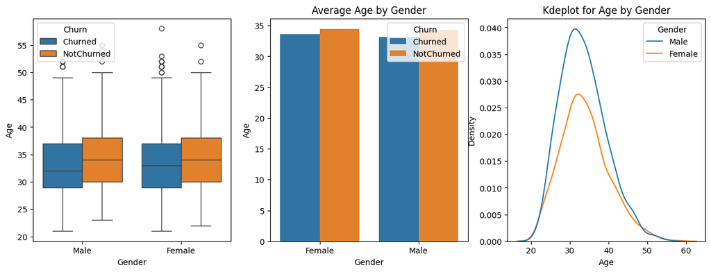

```
   Gender       Churn        Age
0  Female     Churned  33.624251
1  Female  NotChurned  34.449838
2    Male     Churned  33.136076
3    Male  NotChurned  34.280702
```

```python
perform_anova_kruskal(driversWithCategories,numerical_column='Age', categorical_column='Gender', test=test,log="detailed", hueColumn='Churn')
```

Gender and Age are independent. Medians of groups of Age based on Gender are same

In simple words, there’s no substantial Age difference across Gender values

### 3.2.3 Age and City

```
Ho = City and Age are independent. Medians of groups of Age based on City are same
Ha = City and Age are DEPENDENT. Medians of groups of Age based on City are different
Kruskal-Wallis Result:19.116945857154757,0.8944889418402363
Effect Size: η²=-0.00
Fail to Reject Null Hypothesis. Null Hypothesis 'City and Age are independent. Medians of groups of Age based on City are same In simple words, there’s no substantial Age difference across City values' is True, p-value:0.89
```

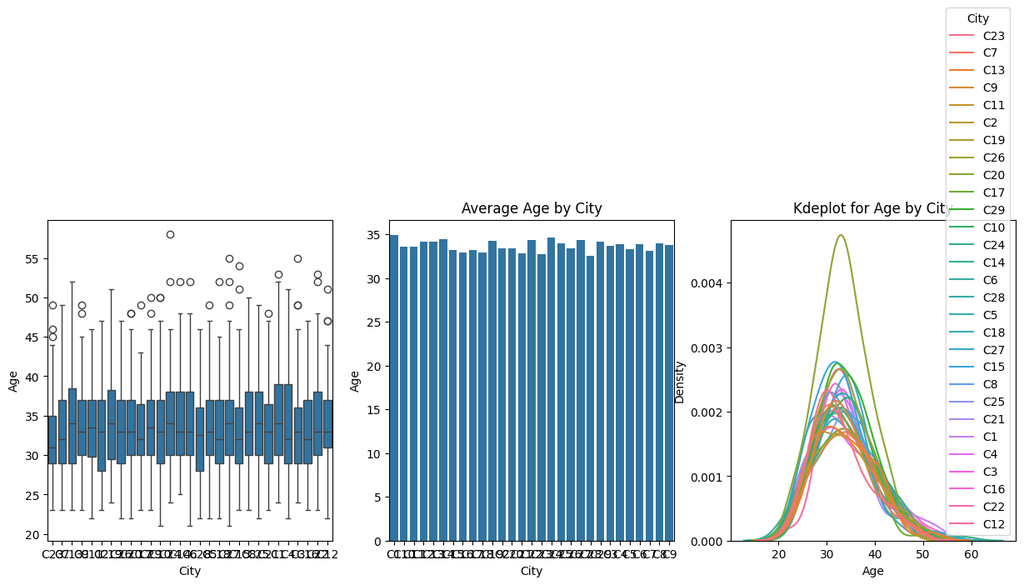

```
   City        Age
0    C1  34.912500
1   C10  33.616279
2   C11  33.578125
3   C12  34.148148
4   C13  34.154930
5   C14  34.405063
6   C15  33.158416
7   C16  32.928571
8   C17  33.197183
9   C18  32.956522
10  C19  34.208333
11   C2  33.347222
12  C20  33.421053
13  C21  32.822785
14  C22  34.304878
15  C23  32.729730
16  C24  34.589041
17  C25  33.959459
18  C26  33.419355
19  C27  34.303371
20  C28  32.536585
21  C29  34.166667
22   C3  33.634146
23   C4  33.883117
24   C5  33.275000
25   C6  33.858974
26   C7  33.118421
27   C8  33.988764
28   C9  33.760000
```

```python
perform_anova_kruskal(drivers,numerical_column='Age', categorical_column='City', test=test,log="detailed")
```

City and Age are independent. Medians of groups of Age based on City are same

### 3.2.4 Age and Education Level

```
Ho = Education_Level and Age are independent. Medians of groups of Age based on Education_Level are same
Ha = Education_Level and Age are DEPENDENT. Medians of groups of Age based on Education_Level are different
Kruskal-Wallis Result:5.715767909743988,0.05739007185174372
Effect Size: η²=0.00
Fail to Reject Null Hypothesis. Null Hypothesis 'Education_Level and Age are independent. Medians of groups of Age based on Education_Level are same In simple words, there’s no substantial Age difference across Education_Level values' is True, p-value:0.06
```

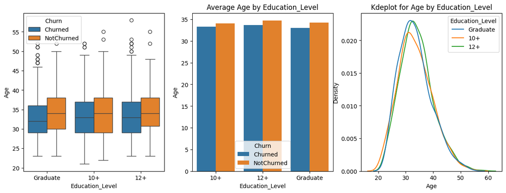

```
  Education_Level       Churn        Age
0             10+     Churned  33.309963
1             10+  NotChurned  34.024793
2             12+     Churned  33.681214
3             12+  NotChurned  34.738806
4        Graduate     Churned  33.034735
5        Graduate  NotChurned  34.247059
```

```python
perform_anova_kruskal(driversWithCategories,numerical_column='Age', categorical_column='Education_Level', test=test,log="detailed", hueColumn='Churn')
```

Education_Level and Age are independent

There’s no substantial age difference across education levels, and churn does not strongly depend on either.

### 3.2.5 Age and Joining Designation

```
Ho = Joining Designation and Age are independent. Medians of groups of Age based on Joining Designation are same
Ha = Joining Designation and Age are DEPENDENT. Medians of groups of Age based on Joining Designation are different
Kruskal-Wallis Result:47.958995786477715,9.625428906028363e-10
Effect Size: η²=0.02
Reject Null Hypothesis. Alternate Hypothesis 'Joining Designation and Age are DEPENDENT. Medians of groups of Age based on Joining Designation are different In simple words, there’s substantial Age difference across Joining Designation values' is True, p-value:0.00.
Joining Designation values vary across Age groups (enough to be statistically significant kruskal p_value=9.625428906028363e-10), Age influence on Joining Designation is considered small (η²=0.02)
```

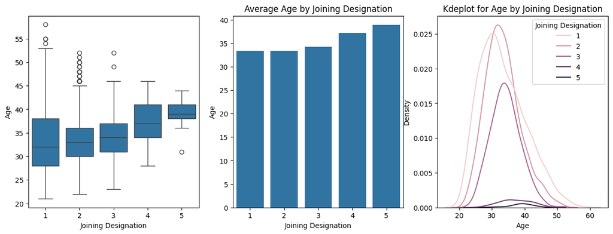

```
   Joining Designation        Age
0                    1  33.411306
1                    2  33.397546
2                    3  34.247465
3                    4  37.222222
4                    5  38.909091
```

```python
perform_anova_kruskal(drivers,numerical_column='Age', categorical_column='Joining Designation', test=test,log="detailed")
```

Joining Designation rates vary slightly across Age groups (enough to be statistically significant kruskal p_value=9.625428906028363e-10), Age influence on Joining Designation is considered small (η²=0.02)

Avg age of drivers joining in designation 1,2 is 33 while those at grade 4,5 is 37 to 40

### 3.2.6 Age and Current Grade

```
Ho = Grade and Age are independent. Medians of groups of Age based on Grade are same
Ha = Grade and Age are DEPENDENT. Medians of groups of Age based on Grade are different
Kruskal-Wallis Result:180.1942034759169,6.773769898624466e-38
Effect Size: η²=0.07
Reject Null Hypothesis. Alternate Hypothesis 'Grade and Age are DEPENDENT. Medians of groups of Age based on Grade are different In simple words, there’s substantial Age difference across Grade values' is True, p-value:0.00.
Grade values vary across Age groups (enough to be statistically significant kruskal p_value=6.773769898624466e-38), Age does have a medium influence on Grade (η²=0.07)
```

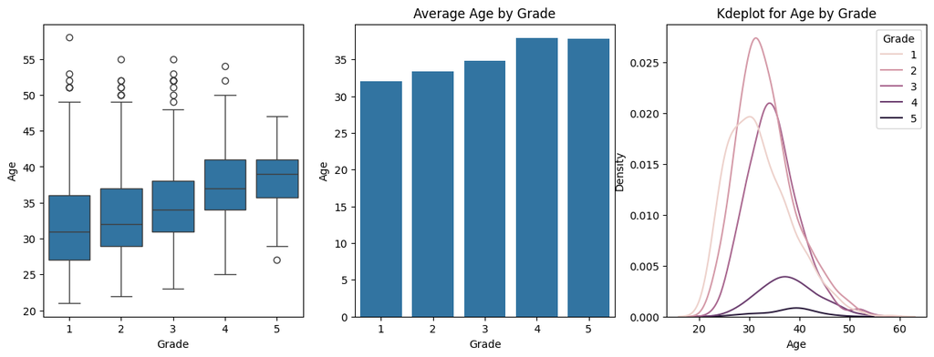

```
   Grade        Age
0      1  32.056680
1      2  33.409357
2      3  34.815409
3      4  37.927536
4      5  37.833333
```

```python
perform_anova_kruskal(drivers,numerical_column='Age', categorical_column='Grade', test=test,log="detailed")
```

Grade rates vary across Age groups (enough to be statistically significant kruskal p_value=6.773769898624466e-38), Age does have a medium influence on Grade (η²=0.07)

Avg age of drivers in grade 1,2,3 is around 33-34 while those at grade 4,5 is 38 to 39

### 3.2.7 Age and Rating Trend

```
Ho = RatingTrend and Age are independent. Medians of groups of Age based on RatingTrend are same
Ha = RatingTrend and Age are DEPENDENT. Medians of groups of Age based on RatingTrend are different
Kruskal-Wallis Result:83.79395463190693,2.7340133727364485e-17
Effect Size: η²=0.03
Reject Null Hypothesis. Alternate Hypothesis 'RatingTrend and Age are DEPENDENT. Medians of groups of Age based on RatingTrend are different In simple words, there’s substantial Age difference across RatingTrend values' is True, p-value:0.00.
RatingTrend values vary across Age groups (enough to be statistically significant kruskal p_value=2.7340133727364485e-17), Age influence on RatingTrend is considered small (η²=0.03)
```

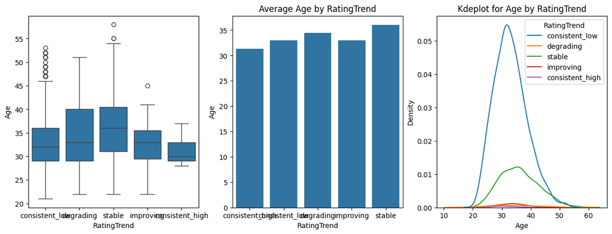

```
       RatingTrend        Age
0  consistent_high  31.285714
1   consistent_low  33.017689
2        degrading  34.483871
3        improving  32.971429
4           stable  36.032064
```

```python
perform_anova_kruskal(drivers,numerical_column='Age', categorical_column='RatingTrend', test=test,log="detailed")
```

RatingTrend values vary across Age groups (enough to be statistically significant kruskal p_value=2.7340133727364485e-17), Age influence on RatingTrend is considered small (η²=0.03)

Youngest drivers (age 31) have consistently high ratings(4,5)

Oldest drivers (age 36) have consistently stable midrange ratings(2,3,4)

Drivers around age 33 have consistently low range ratings(1)

### 3.2.8 Age and Total Business Value

```
🔹 Pearson correlation between Age and Total Business Value: 0.255
🔹 Spearman correlation between Age and Total Business Value: 0.263
```

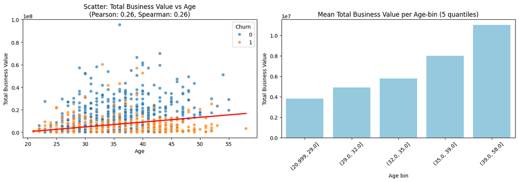

```python
nonZeroTBVDrivers = drivers[drivers['Total Business Value']>0].copy()
numerical_numerical_analysis(nonZeroTBVDrivers,'Age','Total Business Value', hue='Churn')
```

There is a weak positive correlation between Age and Total business value

Contribution to total business value for age group 39+ is triple that of age group 20-29

Contribution to total business value for age group 35-39 is double that of age group 20-29

Drivers who churned generally had less TBV

### 3.2.9 Age and IncomeLast

```
🔹 Pearson correlation between Age and IncomeLast: 0.184
🔹 Spearman correlation between Age and IncomeLast: 0.193
```

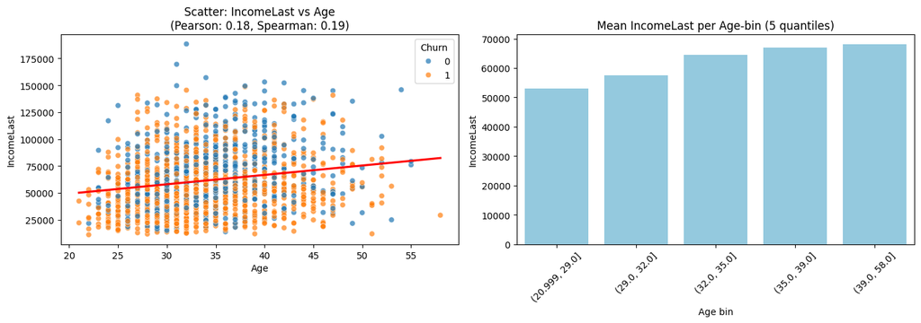

```python
numerical_numerical_analysis(nonZeroTBVDrivers,'Age','IncomeLast', hue='Churn')
```

There is a weak positive correlation between Age and Income

### 3.2.10 Age and RatingMean

```
🔹 Pearson correlation between Age and RatingMean: 0.191
🔹 Spearman correlation between Age and RatingMean: 0.177
```

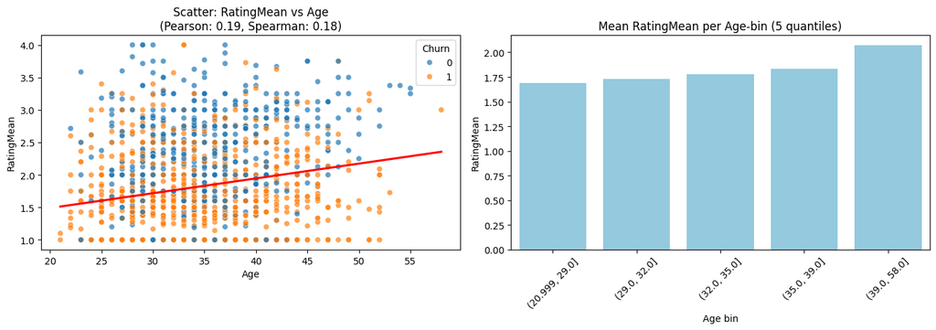

```python
numerical_numerical_analysis(nonZeroTBVDrivers,'Age','RatingMean', hue='Churn')
```

Olders drivers have slightly more mean rating than younger ones, but the correlation of age and rating is very weak

### 3.2.11 Driver Age and EmploymentAge

```
🔹 Pearson correlation between Age and EmploymentAge: 0.299
🔹 Spearman correlation between Age and EmploymentAge: 0.273
```

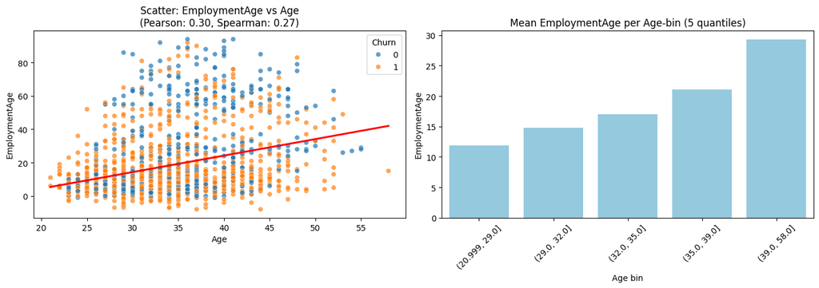

```python
numerical_numerical_analysis(nonZeroTBVDrivers,'Age','EmploymentAge', hue='Churn')
```

Age and Employment age are obviously correlated. An older employee will naturally tend to have a longer employment history. But it does show that employees have stayed with the company for past 7 yrs.

### 3.2.12 Gender and City

```
Contingency Table:
City    C1  C10  C11  C12  C13  C14  C15  C16  C17  C18  ...  C27  C28  C29  \
Gender                                                   ...
Female  37   35   28   30   24   30   34   33   30   33  ...   42   27   35
Male    43   51   36   51   47   49   67   51   41   36  ...   47   55   61

City    C3  C4  C5  C6  C7  C8  C9
Gender
Female  40  31  30  41  35  45  35
Male    42  46  50  37  41  44  40

[2 rows x 29 columns]


Chi-square Test Results:
Chi-square statistic: 35.1509
p-value: 0.1655
Degrees of freedom: 28
Significant at α=0.05: No
Fail to Reject Null Hypothesis. Null Hypothesis '<li>Gender and City are independent.' is True, p-value:0.16551831811805257
```

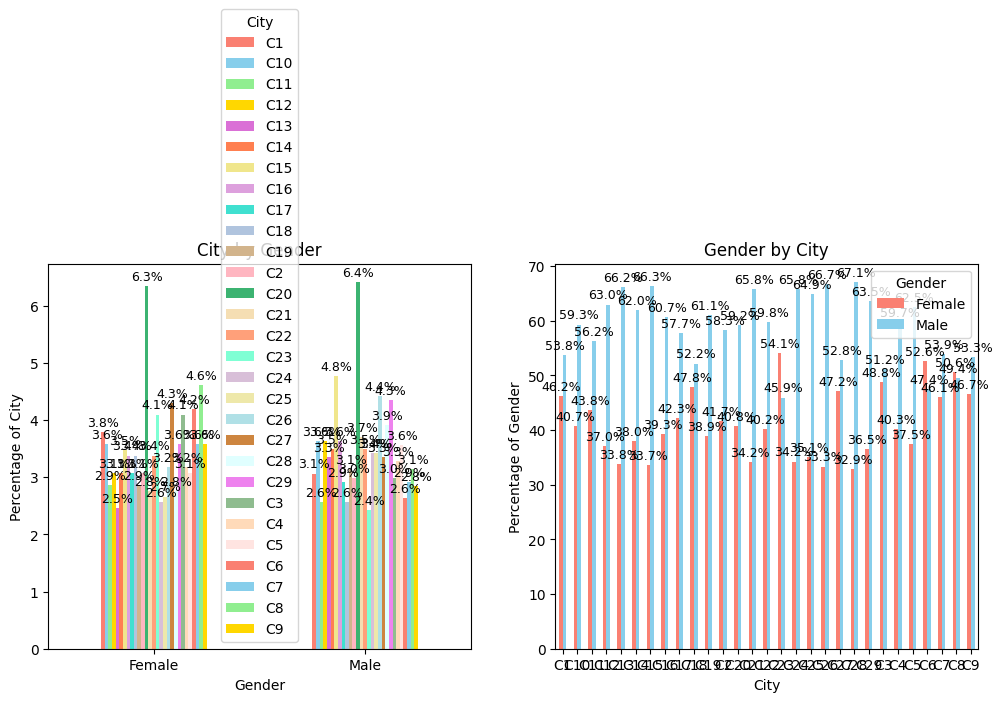

```python
perform_chi_square_test(driversWithCategories,'Gender','City')
```

```python
crosstab = pd.crosstab(drivers.Gender,drivers.City)
cities = crosstab.columns[crosstab.loc[1] > crosstab.loc[0]].tolist()
print(cities)
```

```
['C23', 'C6', 'C8']
```

There is no correlation between gender and city

There are 3 cities 'C23', 'C6', 'C8' out of 29 where females are more than males

```python
percentageMoreMales = np.round(100*(crosstab.loc[0]-crosstab.loc[1] )/(crosstab.loc[0]),2)
percentageMoreMales
```

```
City
C1     13.95
C10    31.37
C11    22.22
C12    41.18
C13    48.94
C14    38.78
C15    49.25
C16    35.29
C17    26.83
C18     8.33
C19    36.36
C2     28.57
C20    31.11
C21    48.08
C22    32.65
C23   -17.65
C24    47.92
C25    45.83
C26    50.00
C27    10.64
C28    50.91
C29    42.62
C3      4.76
C4     32.61
C5     40.00
C6    -10.81
C7     14.63
C8     -2.27
C9     12.50
dtype: float64
```

```python
print(percentageMoreMales[percentageMoreMales>49])
print(percentageMoreMales.mean())
```

```
City
C15    49.25
C26    50.00
C28    50.91
dtype: float64
28.089655172413792
```

### 3.2.13 Gender and Education_Level

```
Contingency Table:
Education_Level  10+  12+  Graduate
Gender
Female           323  332       322
Male             461  463       480


Chi-square Test Results:
Chi-square statistic: 0.4417
p-value: 0.8018
Degrees of freedom: 2
Significant at α=0.05: No
Fail to Reject Null Hypothesis. Null Hypothesis '<li>Gender and Education_Level are independent.' is True, p-value:0.8018290006096183
```

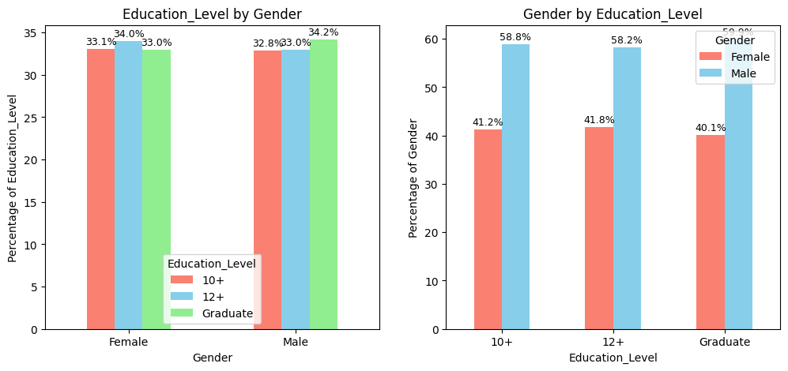

```python
perform_chi_square_test(driversWithCategories,'Gender','Education_Level')
```

Education levels are similar across genders

### 3.2.14 Gender and Date of Joining

```python
df_analysis = driversWithCategories[['Dateofjoining','Gender']].copy()
df_analysis['year'] = df_analysis.Dateofjoining.dt.year
ct = pd.crosstab(df_analysis.year, df_analysis.Gender)
ct['pctMoreMales'] = np.round(100*(ct.Male-ct.Female)/ct.Female,2)
ct['ratioFemaleMale'] = np.round(ct.Female/ct.Male,2)
print(f'In general, company hires {ct['pctMoreMales'].mean()}% more males than female drivers')
print(f'The company hires {np.floor(100*ct['ratioFemaleMale'].mean())} females for every 100 males drivers')
ct
```

```
In general, company hires 37.791250000000005% more males than female drivers
The company hires 73.0 females for every 100 males drivers
```

| Gender year | Female | Male | pctMoreMales | ratioFemaleMale |
| --- | --- | --- | --- | --- |
| 2013 | 18 | 23 | 27.78 | 0.78 |
| 2014 | 12 | 17 | 41.67 | 0.71 |
| 2015 | 50 | 59 | 18.00 | 0.85 |
| 2016 | 47 | 61 | 29.79 | 0.77 |
| 2017 | 35 | 51 | 45.71 | 0.69 |
| 2018 | 253 | 346 | 36.76 | 0.73 |
| 2019 | 232 | 359 | 54.74 | 0.65 |
| 2020 | 330 | 488 | 47.88 | 0.68 |

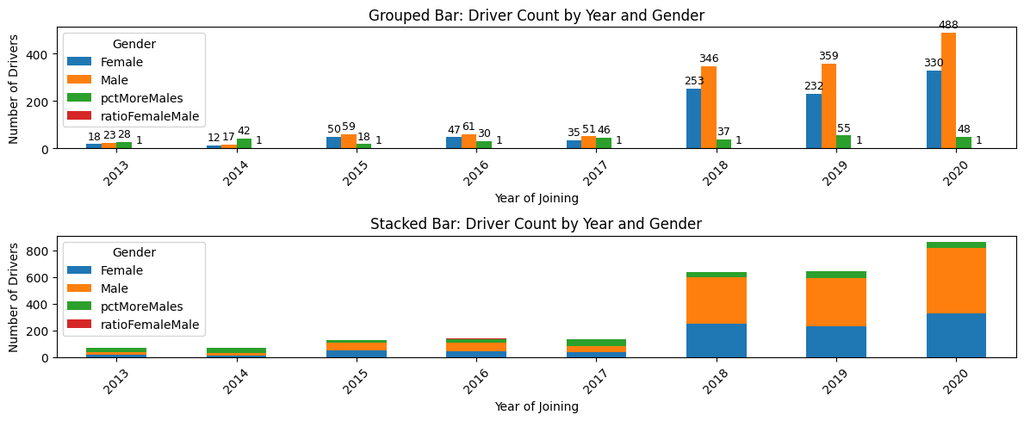

```python
# --- Normal (grouped) bar plot ---
fig, axes = plt.subplots(2, 1, figsize=(12, 5))
bars = ct.plot(kind='bar', ax=axes[0])
axes[0].set_title('Grouped Bar: Driver Count by Year and Gender')
axes[0].set_xlabel('Year of Joining')
axes[0].set_ylabel('Number of Drivers')
axes[0].tick_params(axis='x', rotation=45)
axes[0].legend(title='Gender')
annotate_bars(bars,'%.0f')

# --- Stacked bar plot ---
bars=ct.plot(kind='bar', stacked=True, ax=axes[1])
axes[1].set_title('Stacked Bar: Driver Count by Year and Gender')
axes[1].set_xlabel('Year of Joining')
axes[1].set_ylabel('Number of Drivers')
axes[1].tick_params(axis='x', rotation=45)
axes[1].legend(title='Gender')

plt.tight_layout()
plt.show()
```

### 3.2.15 Gender and LastWorkingDate

```python
df_analysis = driversWithCategories.loc[driversWithCategories.Churn=='Churned'][['LastWorkingDate','Gender']].copy()
df_analysis['year'] = df_analysis.LastWorkingDate.dt.year
print(pd.crosstab(df_analysis.year, df_analysis.Gender, normalize='index'))
```

```
Gender    Female      Male
year
2018    0.400000  0.600000
2019    0.416970  0.583030
2020    0.409669  0.590331
```

The ratio of churn across genders is same as the overall ratio of genders. We can say churn is unaffected by gender.

### 3.2.16 Gender and Joining Designation

```
Contingency Table:
Joining Designation    1    2    3   4  5
Gender
Female               440  334  190  10  3
Male                 586  481  303  26  8


Chi-square Test Results:
Chi-square statistic: 6.1970
p-value: 0.1849
Degrees of freedom: 4
Significant at α=0.05: No
Fail to Reject Null Hypothesis. Null Hypothesis '<li>Gender and Joining Designation are independent.' is True, p-value:0.18490824967273095
```

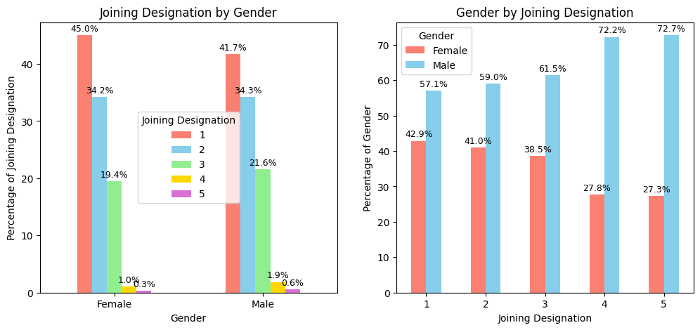

```python
perform_chi_square_test(driversWithCategories,'Gender','Joining Designation')
```

There are lesser females hired at higher joining designations

### 3.2.17 Gender and Joining Grade

```
Contingency Table:
Grade     1    2    3   4   5
Gender
Female  307  348  256  56  10
Male    434  507  367  82  14


Chi-square Test Results:
Chi-square statistic: 0.1037
p-value: 0.9987
Degrees of freedom: 4
Significant at α=0.05: No
Fail to Reject Null Hypothesis. Null Hypothesis '<li>Gender and Grade are independent.' is True, p-value:0.9987002718014714
```

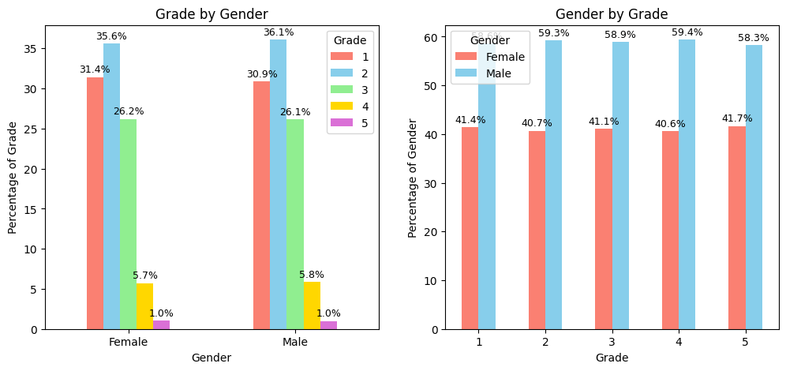

```python
perform_chi_square_test(driversWithCategories,'Gender','Grade')
```

Gender does not have impact on joining grade

### 3.2.18 Gender and GradeIncreased

```
Contingency Table:
GradeIncreased     0    1
Gender
Female           795  182
Male            1179  225


Chi-square Test Results:
Chi-square statistic: 2.5734
p-value: 0.1087
Degrees of freedom: 1
Significant at α=0.05: No
Fail to Reject Null Hypothesis. Null Hypothesis '<li>Gender and GradeIncreased are independent.' is True, p-value:0.10867323802580135
```

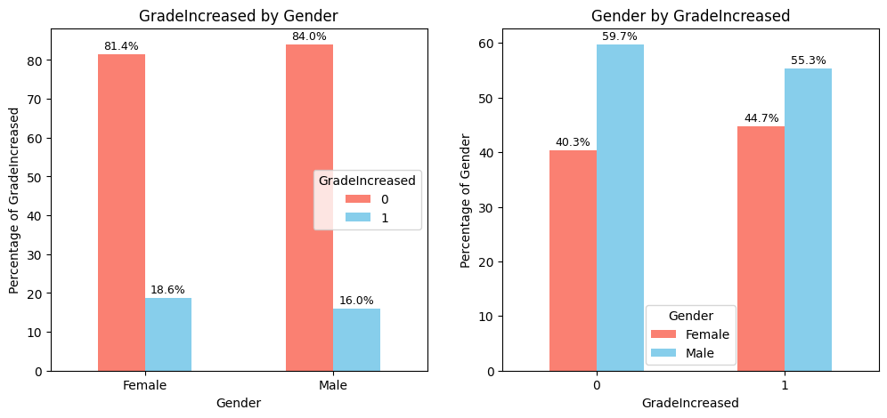

```python
perform_chi_square_test(driversWithCategories,'Gender','GradeIncreased')
```

Gender and GradeIncreased are independent

### 3.2.19 Gender and Total Business Value

```
Ho = Gender and Total Business Value are independent. Medians of groups of Total Business Value based on Gender are same
Ha = Gender and Total Business Value are DEPENDENT. Medians of groups of Total Business Value based on Gender are different
Kruskal-Wallis Result:0.933393696679572,0.33398262504199605
Effect Size: η²=-0.00
Fail to Reject Null Hypothesis. Null Hypothesis 'Gender and Total Business Value are independent. Medians of groups of Total Business Value based on Gender are same In simple words, there’s no substantial Total Business Value difference across Gender values' is True, p-value:0.33
```

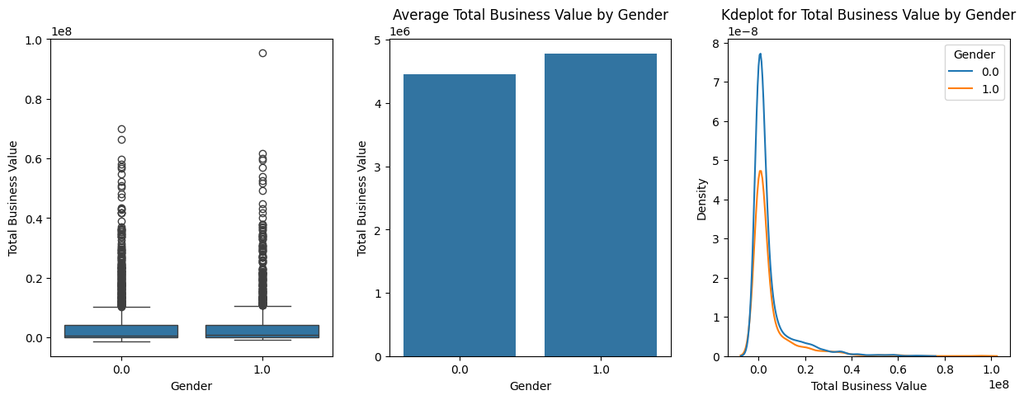

```
   Gender  Total Business Value
0     0.0          4.453073e+06
1     1.0          4.778831e+06
```

```python
perform_anova_kruskal(drivers,numerical_column='Total Business Value', categorical_column='Gender', test=test,log="detailed")
```

Gender does not affect Total Business Value

### 3.2.20 Gender and Quarterly Rating

```
Contingency Table:
Quarterly Rating     1    2    3   4
Gender
Female             703  158   65  51
Male              1041  204  103  56


Chi-square Test Results:
Chi-square statistic: 3.7242
p-value: 0.2928
Degrees of freedom: 3
Significant at α=0.05: No
Fail to Reject Null Hypothesis. Null Hypothesis '<li>Gender and Quarterly Rating are independent.' is True, p-value:0.2928275069846611
```

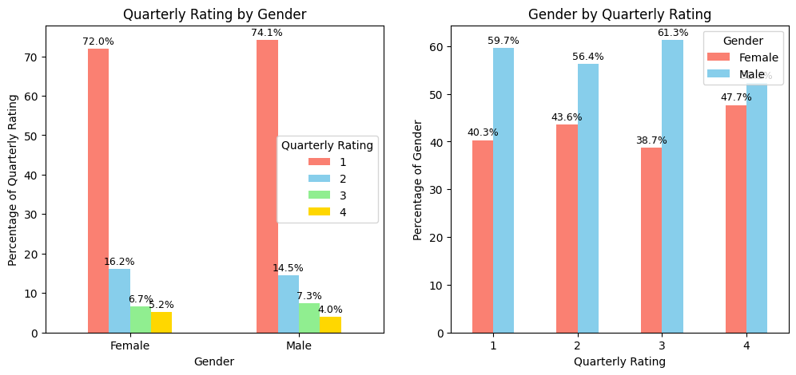

```python
perform_chi_square_test(driversWithCategories,'Gender','Quarterly Rating')
```

Quarterly Rating are similar across genders

### 3.2.21 Gender and Income

```
Ho = Gender and IncomeLast are independent. Medians of groups of IncomeLast based on Gender are same
Ha = Gender and IncomeLast are DEPENDENT. Medians of groups of IncomeLast based on Gender are different
Kruskal-Wallis Result:0.3846149964109669,0.5351436584318934
Effect Size: η²=-0.00
Fail to Reject Null Hypothesis. Null Hypothesis 'Gender and IncomeLast are independent. Medians of groups of IncomeLast based on Gender are same In simple words, there’s no substantial IncomeLast difference across Gender values' is True, p-value:0.54
```

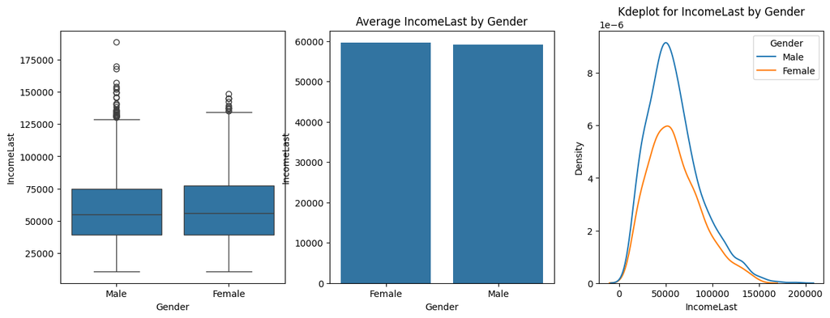

```
   Gender    IncomeLast
0  Female  59587.636643
1    Male  59157.768519
```

```python
perform_anova_kruskal(driversWithCategories,numerical_column='IncomeLast', categorical_column='Gender', test=test,log="detailed")
```

Gender does not affect Income

### 3.2.22 Gender and Rating

```
Ho = Gender and RatingMean are independent. Medians of groups of RatingMean based on Gender are same
Ha = Gender and RatingMean are DEPENDENT. Medians of groups of RatingMean based on Gender are different
Kruskal-Wallis Result:0.003339625424636433,0.9539163080918562
Effect Size: η²=-0.00
Fail to Reject Null Hypothesis. Null Hypothesis 'Gender and RatingMean are independent. Medians of groups of RatingMean based on Gender are same In simple words, there’s no substantial RatingMean difference across Gender values' is True, p-value:0.95
```

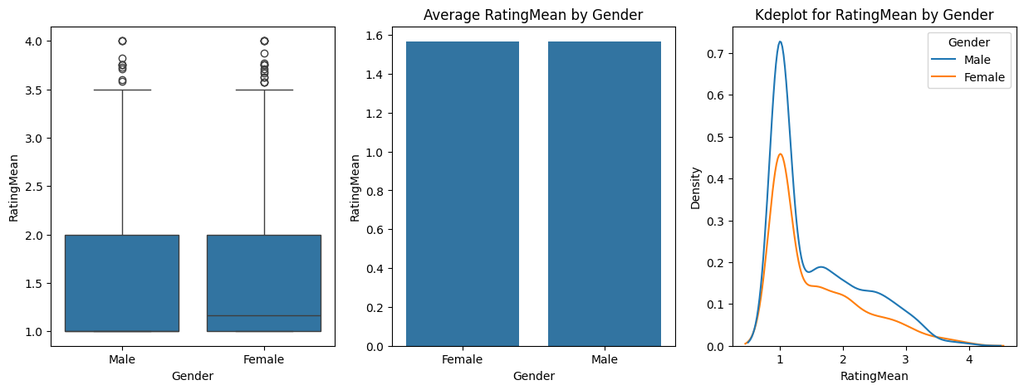

```
   Gender  RatingMean
0  Female    1.566544
1    Male    1.566137
```

```python
perform_anova_kruskal(driversWithCategories,numerical_column='RatingMean', categorical_column='Gender', test=test,log="detailed")
```

Ratings are similar across genders

### 3.2.23 Gender and RatingTrend

```
Contingency Table:
RatingTrend  consistent_high  consistent_low  degrading  improving  stable
Gender
Female                     4             750          7         11     205
Male                       3            1059         24         24     294


Chi-square Test Results:
Chi-square statistic: 6.5840
p-value: 0.1596
Degrees of freedom: 4
Significant at α=0.05: No
Fail to Reject Null Hypothesis. Null Hypothesis '<li>Gender and RatingTrend are independent.' is True, p-value:0.1595769367752142
```

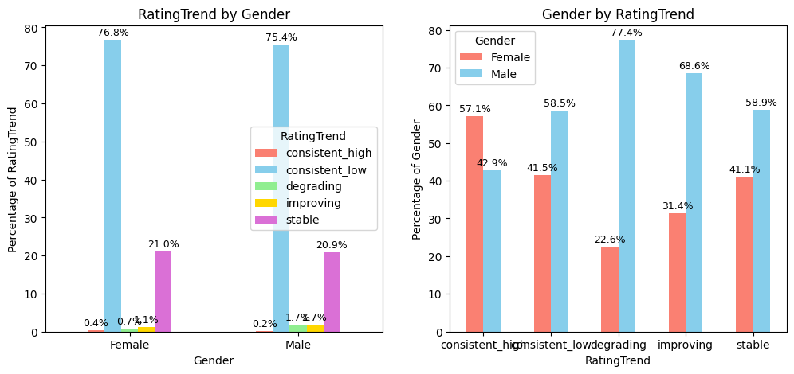

```python
perform_chi_square_test(driversWithCategories,'Gender','RatingTrend')
```

There are more women than men that have consistently high ratings

For drivers whose rating is degrading, the ratio of men is more than the general ratio of men to women. It means a larger percentage of men have degrading performance rating.

### 3.2.24 Gender and Churn

```
Contingency Table:
Churn   Churned  NotChurned
Gender
Female      668         309
Male        948         456


Chi-square Test Results:
Chi-square statistic: 0.1544
p-value: 0.6944
Degrees of freedom: 1
Significant at α=0.05: No
Fail to Reject Null Hypothesis. Null Hypothesis '<li>Gender and Churn are independent.' is True, p-value:0.6943902798506425
```

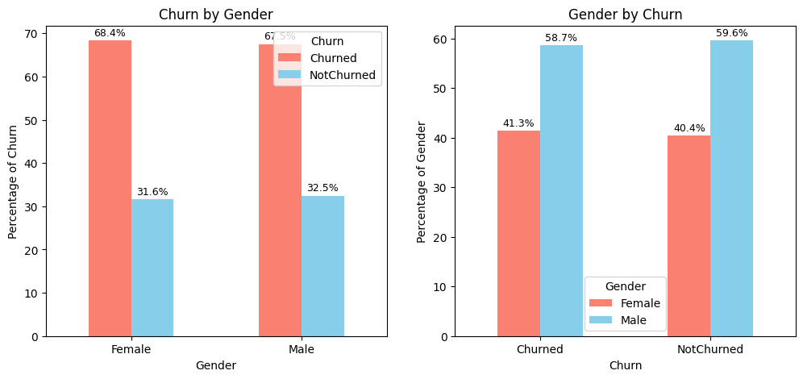

```python
perform_chi_square_test(driversWithCategories,'Gender','Churn')
```

Churn is similar across genders

### 3.2.25 Gender and EmploymentAge

```
Ho = Gender and EmploymentAge are independent. Medians of groups of EmploymentAge based on Gender are same
Ha = Gender and EmploymentAge are DEPENDENT. Medians of groups of EmploymentAge based on Gender are different
Kruskal-Wallis Result:0.21097233242125069,0.6460063650316499
Effect Size: η²=-0.00
Fail to Reject Null Hypothesis. Null Hypothesis 'Gender and EmploymentAge are independent. Medians of groups of EmploymentAge based on Gender are same In simple words, there’s no substantial EmploymentAge difference across Gender values' is True, p-value:0.65
```

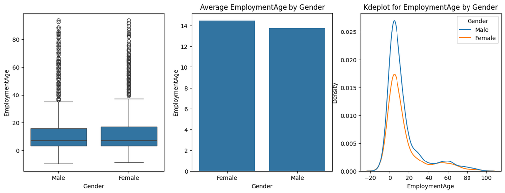

```
   Gender  EmploymentAge
0  Female      14.479017
1    Male      13.763533
```

```python
perform_anova_kruskal(driversWithCategories,numerical_column='EmploymentAge', categorical_column='Gender', test=test,log="detailed")
```

There’s no substantial EmploymentAge difference across Gender values

### 3.2.26 JoiningDate and LastWorkingDate

- We created two series earlier -monthly_counts_series_joinees, monthly_counts_series_churn
- Lets analyze them together to compare hiring and churning trends

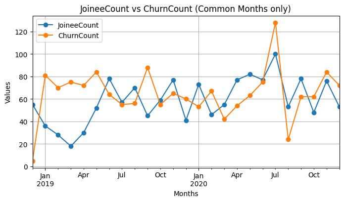

```python
df_analysis = pd.concat([monthly_counts_series_joinees, monthly_counts_series_churn], axis=1, join='inner')
df_analysis.columns = ['JoineeCount', 'ChurnCount']
# Plot both columns
df_analysis.plot(kind='line', marker='o', figsize=(8,4))
plt.title('JoineeCount vs ChurnCount (Common Months only)')
plt.xlabel('Months')
plt.ylabel('Values')
plt.grid(True)
plt.show()
```

```python
df_analysis.sum(axis=0)
```

```
JoineeCount    1464
ChurnCount     1616
dtype: int64
```

This comparison reveals a stark reality of the hiring numbers and state of affairs in the company.

While we were under impresssion earlier that hiring has increased, these numbers show that churn has increased even further.

So while 1464 drivers joined, 1616 drivers left the company !!

### 3.2.27 Churn and City

```
Contingency Table:
Churn  Churned  NotChurned
City
C1          56          24
C10         61          25
C11         45          19
C12         53          28
C13         58          13
C14         58          21
C15         69          32
C16         50          34
C17         55          16
C18         44          25
C19         41          31
C2          55          17
C20        111          41
C21         48          31
C22         50          32
C23         57          17
C24         51          22
C25         54          20
C26         65          28
C27         60          29
C28         59          23
C29         51          45
C3          52          30
C4          52          25
C5          48          32
C6          55          23
C7          52          24
C8          53          36
C9          53          22


Chi-square Test Results:
Chi-square statistic: 46.9172
p-value: 0.0140
Degrees of freedom: 28
Significant at α=0.05: Yes
Reject Null Hypothesis. Alternate Hypothesis '<li>City and Churn are DEPENDENT' is True, p-value:0.013977549937173567. However, association is Weak(CramersV=0.14)
```

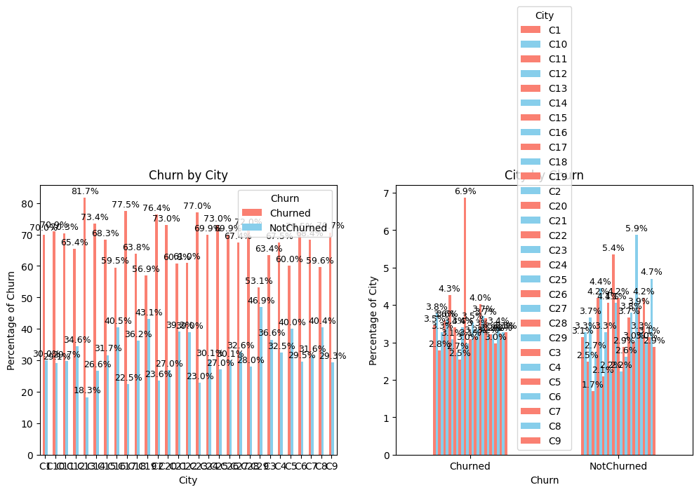

```python
perform_chi_square_test(driversWithCategories,'City','Churn')
```

City and Churn are DEPENDENT. It means some cities have more churn compared to others. p-value:0.013977549937173567. However, association is Weak(CramersV=0.14)

#### Analyse join and churn trend across cities

We want to analyse the joining and churning trend in the cities over the months so as to find if there is any city that has abnormally high data.

```python
df_original
```

|  | MMM-YY | Driver_ID | Age | Gender | City | Education_Level | Income | Dateofjoining | LastWorkingDate | Joining Designation | Grade | Total Business Value | Quarterly Rating |
| --- | --- | --- | --- | --- | --- | --- | --- | --- | --- | --- | --- | --- | --- |
| 0 | 2019-01-01 | 1 | 28.0 | 0.0 | C23 | 2 | 57387 | 2018-12-24 | 2067-12-31 | 1 | 1 | 2381060 | 2 |
| 1 | 2019-02-01 | 1 | 28.0 | 0.0 | C23 | 2 | 57387 | 2018-12-24 | 2067-12-31 | 1 | 1 | -665480 | 2 |
| 2 | 2019-03-01 | 1 | 28.0 | 0.0 | C23 | 2 | 57387 | 2018-12-24 | 2019-11-03 | 1 | 1 | 0 | 2 |
| 3 | 2020-11-01 | 2 | 31.0 | 0.0 | C7 | 2 | 67016 | 2020-06-11 | 2067-12-31 | 2 | 2 | 0 | 1 |
| 4 | 2020-12-01 | 2 | 31.0 | 0.0 | C7 | 2 | 67016 | 2020-06-11 | 2067-12-31 | 2 | 2 | 0 | 1 |
| ... | ... | ... | ... | ... | ... | ... | ... | ... | ... | ... | ... | ... | ... |
| 19099 | 2020-08-01 | 2788 | 30.0 | 0.0 | C27 | 2 | 70254 | 2020-08-06 | 2067-12-31 | 2 | 2 | 740280 | 3 |
| 19100 | 2020-09-01 | 2788 | 30.0 | 0.0 | C27 | 2 | 70254 | 2020-08-06 | 2067-12-31 | 2 | 2 | 448370 | 3 |
| 19101 | 2020-10-01 | 2788 | 30.0 | 0.0 | C27 | 2 | 70254 | 2020-08-06 | 2067-12-31 | 2 | 2 | 0 | 2 |
| 19102 | 2020-11-01 | 2788 | 30.0 | 0.0 | C27 | 2 | 70254 | 2020-08-06 | 2067-12-31 | 2 | 2 | 200420 | 2 |
| 19103 | 2020-12-01 | 2788 | 30.0 | 0.0 | C27 | 2 | 70254 | 2020-08-06 | 2067-12-31 | 2 | 2 | 411480 | 2 |

19104 rows × 13 columns

```python
df_original.columns
```

```
Index(['MMM-YY', 'Driver_ID', 'Age', 'Gender', 'City', 'Education_Level',
       'Income', 'Dateofjoining', 'LastWorkingDate', 'Joining Designation',
       'Grade', 'Total Business Value', 'Quarterly Rating'],
      dtype='object')
```

```python
df_original['EmploymentStatus'] = np.where(df_original.LastWorkingDate.dt.year==2067,1,0)
df_original
```

|  | MMM-YY | Driver_ID | Age | Gender | City | Education_Level | Income | Dateofjoining | LastWorkingDate | Joining Designation | Grade | Total Business Value | Quarterly Rating | EmploymentStatus |
| --- | --- | --- | --- | --- | --- | --- | --- | --- | --- | --- | --- | --- | --- | --- |
| 0 | 2019-01-01 | 1 | 28.0 | 0.0 | C23 | 2 | 57387 | 2018-12-24 | 2067-12-31 | 1 | 1 | 2381060 | 2 | 1 |
| 1 | 2019-02-01 | 1 | 28.0 | 0.0 | C23 | 2 | 57387 | 2018-12-24 | 2067-12-31 | 1 | 1 | -665480 | 2 | 1 |
| 2 | 2019-03-01 | 1 | 28.0 | 0.0 | C23 | 2 | 57387 | 2018-12-24 | 2019-11-03 | 1 | 1 | 0 | 2 | 0 |
| 3 | 2020-11-01 | 2 | 31.0 | 0.0 | C7 | 2 | 67016 | 2020-06-11 | 2067-12-31 | 2 | 2 | 0 | 1 | 1 |
| 4 | 2020-12-01 | 2 | 31.0 | 0.0 | C7 | 2 | 67016 | 2020-06-11 | 2067-12-31 | 2 | 2 | 0 | 1 | 1 |
| ... | ... | ... | ... | ... | ... | ... | ... | ... | ... | ... | ... | ... | ... | ... |
| 19099 | 2020-08-01 | 2788 | 30.0 | 0.0 | C27 | 2 | 70254 | 2020-08-06 | 2067-12-31 | 2 | 2 | 740280 | 3 | 1 |
| 19100 | 2020-09-01 | 2788 | 30.0 | 0.0 | C27 | 2 | 70254 | 2020-08-06 | 2067-12-31 | 2 | 2 | 448370 | 3 | 1 |
| 19101 | 2020-10-01 | 2788 | 30.0 | 0.0 | C27 | 2 | 70254 | 2020-08-06 | 2067-12-31 | 2 | 2 | 0 | 2 | 1 |
| 19102 | 2020-11-01 | 2788 | 30.0 | 0.0 | C27 | 2 | 70254 | 2020-08-06 | 2067-12-31 | 2 | 2 | 200420 | 2 | 1 |
| 19103 | 2020-12-01 | 2788 | 30.0 | 0.0 | C27 | 2 | 70254 | 2020-08-06 | 2067-12-31 | 2 | 2 | 411480 | 2 | 1 |

19104 rows × 14 columns

```python
city_monthly_data = df_original.groupby(["City","MMM-YY"],as_index=False).EmploymentStatus.sum()
city_monthly_data
```

|  | City | MMM-YY | EmploymentStatus |
| --- | --- | --- | --- |
| 0 | C1 | 2019-01-01 | 39 |
| 1 | C1 | 2019-02-01 | 39 |
| 2 | C1 | 2019-03-01 | 35 |
| 3 | C1 | 2019-04-01 | 32 |
| 4 | C1 | 2019-05-01 | 29 |
| ... | ... | ... | ... |
| 691 | C9 | 2020-08-01 | 20 |
| 692 | C9 | 2020-09-01 | 21 |
| 693 | C9 | 2020-10-01 | 20 |
| 694 | C9 | 2020-11-01 | 19 |
| 695 | C9 | 2020-12-01 | 22 |

696 rows × 3 columns

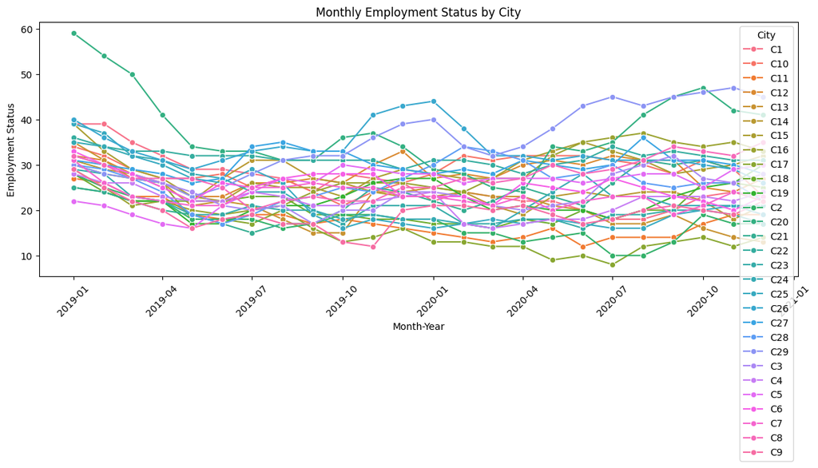

```python
# Create line plot
plt.figure(figsize=(12, 6))
sns.lineplot(
    data=city_monthly_data,
    x='MMM-YY',
    y='EmploymentStatus',
    hue='City',
    marker='o'
)

plt.title('Monthly Employment Status by City')
plt.xlabel('Month-Year')
plt.ylabel('Employment Status')
plt.xticks(rotation=45)
plt.tight_layout()
plt.show()
```

- With 29 cities, it’s visually overloaded graph.
- We can use a facet grid to show one small multiple per city

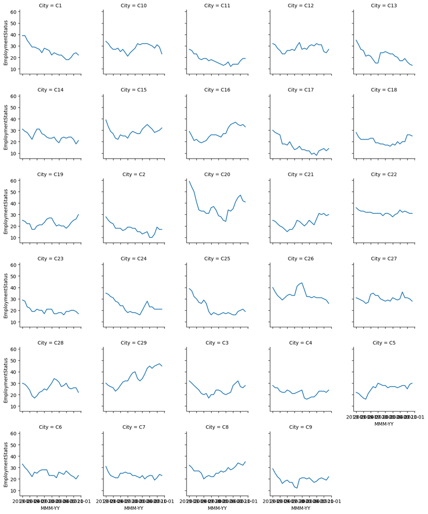

```python
g = sns.FacetGrid(city_monthly_data, col='City', col_wrap=5, height=2.5)
g.map(sns.lineplot, 'MMM-YY', 'EmploymentStatus')
```

#### Focus on top cities

- As cities are too many, let us start by focusing on key cities
- Top 5 cities by average employment

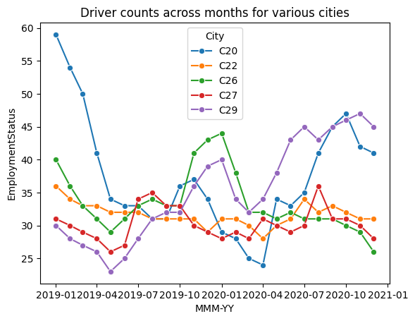

```python
top_cities = (
    city_monthly_data.groupby('City')['EmploymentStatus']
    .mean()
    .sort_values(ascending=False)
    .head(5)
    .index
)

filtered = city_monthly_data[city_monthly_data['City'].isin(top_cities)]

sns.lineplot(data=filtered, x='MMM-YY', y='EmploymentStatus', hue='City', marker='o')
plt.title("Driver counts across months for various cities")
```

In 4 of the top 5 employing cities (c20,C22,C26,C27), the employee count DECREASED over the last two years Only in one of the top 5 cities, C29 has the count increased.

- Let us try to analyse City stability / volatility
- We will do this by measuring the standard deviation of driver counts per city

```python
employeeStabilityAtCityLevel = city_monthly_data.groupby('City',as_index=False)['EmploymentStatus'].std().sort_values(by='EmploymentStatus')
employeeStabilityAtCityLevel.rename(columns={'EmploymentStatus':'DriverCount'}, inplace=True)
employeeStabilityAtCityLevel
```

|  | City | DriverCount |
| --- | --- | --- |
| 14 | C22 | 1.689160 |
| 26 | C7 | 2.484371 |
| 19 | C27 | 2.489107 |
| 3 | C12 | 2.947610 |
| 23 | C4 | 3.020462 |
| 25 | C6 | 3.050006 |
| 15 | C23 | 3.141298 |
| 9 | C18 | 3.331884 |
| 10 | C19 | 3.335144 |
| 1 | C10 | 3.400501 |
| 28 | C9 | 3.476370 |
| 5 | C14 | 3.574264 |
| 2 | C11 | 3.943211 |
| 24 | C5 | 3.963603 |
| 6 | C15 | 4.071819 |
| 27 | C8 | 4.096437 |
| 11 | C2 | 4.230454 |
| 22 | C3 | 4.250959 |
| 20 | C28 | 4.333891 |
| 18 | C26 | 4.568322 |
| 13 | C21 | 4.693312 |
| 4 | C13 | 5.368824 |
| 16 | C24 | 5.453193 |
| 7 | C16 | 5.785884 |
| 0 | C1 | 5.810878 |
| 8 | C17 | 6.068301 |
| 17 | C25 | 6.940221 |
| 21 | C29 | 7.511223 |
| 12 | C20 | 8.811122 |

Cities C22, C7, C27 and C12 have lower attrition rates and stable number of drivers.

```python
employeeStabilityAtCityLevel[-5:]
```

|  | City | DriverCount |
| --- | --- | --- |
| 0 | C1 | 5.810878 |
| 8 | C17 | 6.068301 |
| 17 | C25 | 6.940221 |
| 21 | C29 | 7.511223 |
| 12 | C20 | 8.811122 |

```python
employeeStabilityAtCityLevel[-5:].index
```

```
Index([0, 8, 17, 21, 12], dtype='int64')
```

Cities C20, C29, C25, C17, C1 have very high volatility in driver count.

C20 and C29 are amonng the top 5 employer cities

For C29 the driver count has incresed the maximum

Lets plot this data for further understanding.

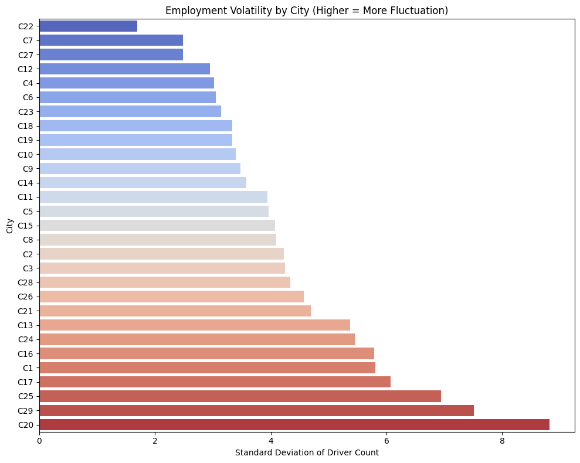

```python
plt.figure(figsize=(10, 8))
sns.barplot(
    data=employeeStabilityAtCityLevel,
    y='City',
    x='DriverCount',
    palette='coolwarm'
)
plt.title('Employment Volatility by City (Higher = More Fluctuation)')
plt.xlabel('Standard Deviation of Driver Count')
plt.ylabel('City')
plt.tight_layout()
plt.show()
```

This plot helps easily identify cities with huge volatility in number of drivers versus those that have relatively stable driver count.

### 3.2.28 Churn and Education Level

```
Contingency Table:
Churn            Churned  NotChurned
Education_Level
10+                  542         242
12+                  527         268
Graduate             547         255


Chi-square Test Results:
Chi-square statistic: 1.5253
p-value: 0.4664
Degrees of freedom: 2
Significant at α=0.05: No
Fail to Reject Null Hypothesis. Null Hypothesis '<li>Education_Level and Churn are independent.' is True, p-value:0.46643939521309963
```

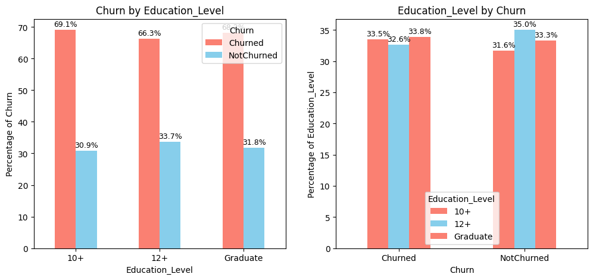

```python
perform_chi_square_test(driversWithCategories,'Education_Level','Churn')
```

Churn is similar across education levels

### 3.2.29 Churn and Date of Joining

At month level EmploymentStatus column is roughly our churn

```python
employmentStatus_monthly_data = df_original.groupby(['MMM-YY'], as_index=False).EmploymentStatus.agg({'sum','count'})
employmentStatus_monthly_data['ChurnedEmployees']=employmentStatus_monthly_data.eval('count-sum')
employmentStatus_monthly_data.rename(columns={'count':'TotalEmployees','sum':'ActiveEmployees'},inplace=True)
employmentStatus_monthly_data
```

|  | MMM-YY | ActiveEmployees | TotalEmployees | ChurnedEmployees |
| --- | --- | --- | --- | --- |
| 0 | 2019-01-01 | 938 | 1022 | 84 |
| 1 | 2019-02-01 | 869 | 944 | 75 |
| 2 | 2019-03-01 | 795 | 870 | 75 |
| 3 | 2019-04-01 | 746 | 794 | 48 |
| 4 | 2019-05-01 | 663 | 764 | 101 |
| 5 | 2019-06-01 | 671 | 726 | 55 |
| 6 | 2019-07-01 | 699 | 757 | 58 |
| 7 | 2019-08-01 | 707 | 754 | 47 |
| 8 | 2019-09-01 | 673 | 762 | 89 |
| 9 | 2019-10-01 | 677 | 739 | 62 |
| 10 | 2019-11-01 | 716 | 781 | 65 |
| 11 | 2019-12-01 | 729 | 795 | 66 |
| 12 | 2020-01-01 | 715 | 782 | 67 |
| 13 | 2020-02-01 | 689 | 761 | 72 |
| 14 | 2020-03-01 | 660 | 719 | 59 |
| 15 | 2020-04-01 | 683 | 729 | 46 |
| 16 | 2020-05-01 | 703 | 766 | 63 |
| 17 | 2020-06-01 | 708 | 770 | 62 |
| 18 | 2020-07-01 | 719 | 806 | 87 |
| 19 | 2020-08-01 | 742 | 812 | 70 |
| 20 | 2020-09-01 | 748 | 809 | 61 |
| 21 | 2020-10-01 | 756 | 818 | 62 |
| 22 | 2020-11-01 | 741 | 805 | 64 |
| 23 | 2020-12-01 | 741 | 819 | 78 |

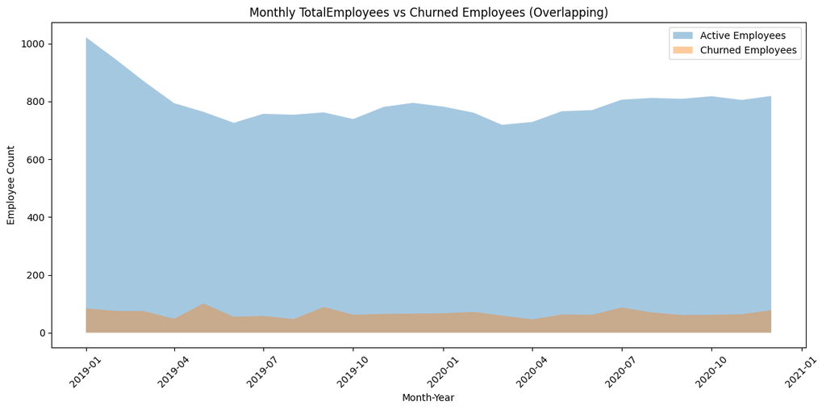

```python
plt.figure(figsize=(12, 6))
plt.fill_between(
    employmentStatus_monthly_data['MMM-YY'],
    employmentStatus_monthly_data['TotalEmployees'],
    alpha=0.4, label='Active Employees'
)
plt.fill_between(
    employmentStatus_monthly_data['MMM-YY'],
    employmentStatus_monthly_data['ChurnedEmployees'],
    alpha=0.4, label='Churned Employees'
)

plt.title('Monthly TotalEmployees vs Churned Employees (Overlapping)')
plt.xlabel('Month-Year')
plt.ylabel('Employee Count')
plt.legend()
plt.xticks(rotation=45)
plt.tight_layout()
plt.show()
```

The plot shows that driver count in the company has remained lower that what it was in start of 2019

```python
employmentStatus_monthly_data['AttritionRate'] = np.round(employmentStatus_monthly_data.eval('ChurnedEmployees*100/(ActiveEmployees + ChurnedEmployees)'),1)
employmentStatus_monthly_data
```

|  | MMM-YY | ActiveEmployees | TotalEmployees | ChurnedEmployees | AttritionRate |
| --- | --- | --- | --- | --- | --- |
| 0 | 2019-01-01 | 938 | 1022 | 84 | 8.2 |
| 1 | 2019-02-01 | 869 | 944 | 75 | 7.9 |
| 2 | 2019-03-01 | 795 | 870 | 75 | 8.6 |
| 3 | 2019-04-01 | 746 | 794 | 48 | 6.0 |
| 4 | 2019-05-01 | 663 | 764 | 101 | 13.2 |
| 5 | 2019-06-01 | 671 | 726 | 55 | 7.6 |
| 6 | 2019-07-01 | 699 | 757 | 58 | 7.7 |
| 7 | 2019-08-01 | 707 | 754 | 47 | 6.2 |
| 8 | 2019-09-01 | 673 | 762 | 89 | 11.7 |
| 9 | 2019-10-01 | 677 | 739 | 62 | 8.4 |
| 10 | 2019-11-01 | 716 | 781 | 65 | 8.3 |
| 11 | 2019-12-01 | 729 | 795 | 66 | 8.3 |
| 12 | 2020-01-01 | 715 | 782 | 67 | 8.6 |
| 13 | 2020-02-01 | 689 | 761 | 72 | 9.5 |
| 14 | 2020-03-01 | 660 | 719 | 59 | 8.2 |
| 15 | 2020-04-01 | 683 | 729 | 46 | 6.3 |
| 16 | 2020-05-01 | 703 | 766 | 63 | 8.2 |
| 17 | 2020-06-01 | 708 | 770 | 62 | 8.1 |
| 18 | 2020-07-01 | 719 | 806 | 87 | 10.8 |
| 19 | 2020-08-01 | 742 | 812 | 70 | 8.6 |
| 20 | 2020-09-01 | 748 | 809 | 61 | 7.5 |
| 21 | 2020-10-01 | 756 | 818 | 62 | 7.6 |
| 22 | 2020-11-01 | 741 | 805 | 64 | 8.0 |
| 23 | 2020-12-01 | 741 | 819 | 78 | 9.5 |

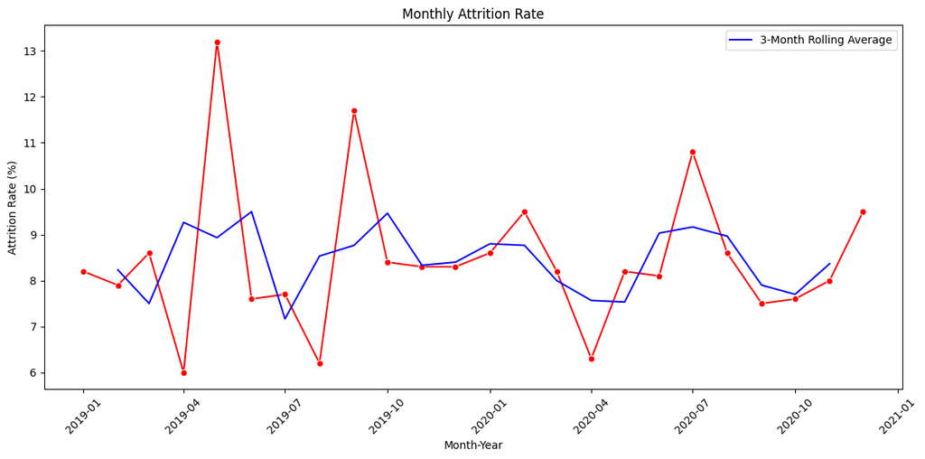

```
np.float64(8.458333333333334)
```

```python
plt.figure(figsize=(12, 6))
sns.lineplot(
    data=employmentStatus_monthly_data,
    x='MMM-YY',
    y='AttritionRate',
    marker='o',
    color='red'
)


employmentStatus_monthly_data['AttritionRate_Rolling'] = (
    employmentStatus_monthly_data['AttritionRate']
    .rolling(window=3, center=True)
    .mean()
)

sns.lineplot(
    data=employmentStatus_monthly_data,
    x='MMM-YY',
    y='AttritionRate_Rolling',
    color='blue',
    label='3-Month Rolling Average'
)

plt.title('Monthly Attrition Rate')
plt.xlabel('Month-Year')
plt.ylabel('Attrition Rate (%)')
plt.xticks(rotation=45)
plt.tight_layout()
plt.show()

meanMonthlyAttritionRate = employmentStatus_monthly_data.AttritionRate.mean()
meanMonthlyAttritionRate
```

Mean monthly attrition is 8.46%. However this does not mean that yearly attrition = 8.46%.

Attrition rates compound over time — so the yearly attrition will actually be much higher.

If 8.45% of employees leave every month, only 91.55% remain after each month.

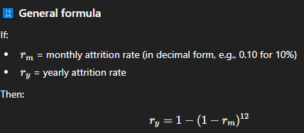

```python
yearly_rate = 1 - (1 - meanMonthlyAttritionRate/100) ** 12
print(f"Yearly attrition ≈ {yearly_rate * 100:.1f}%")
```

```
Yearly attrition ≈ 65.4%
```

Yearly attrition rate is 65.4%

### 3.2.30 Churn and Joining Designation

```
Contingency Table:
Joining Designation    1    2    3   4  5
Churn
Churned              752  560  274  22  8
NotChurned           274  255  219  14  3


Chi-square Test Results:
Chi-square statistic: 49.1405
p-value: 0.0000
Degrees of freedom: 4
Significant at α=0.05: Yes
Reject Null Hypothesis. Alternate Hypothesis '<li>Churn and Joining Designation are DEPENDENT' is True, p-value:5.457615375535053e-10. However, association is Weak(CramersV=0.14)
```

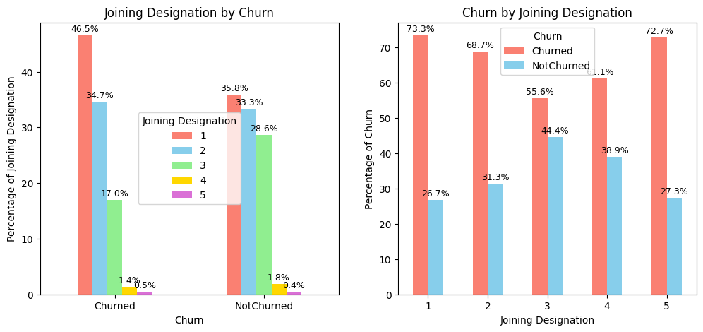

```python
perform_chi_square_test(driversWithCategories,'Churn','Joining Designation')
```

```python
crossNormalized12 = pd.crosstab(driversWithCategories['Churn'], driversWithCategories['Joining Designation'], normalize='columns')
crossNormalized12
```

| Joining Designation Churn | 1 | 2 | 3 | 4 | 5 |
| --- | --- | --- | --- | --- | --- |
| Churned | 0.732943 | 0.687117 | 0.555781 | 0.611111 | 0.727273 |
| NotChurned | 0.267057 | 0.312883 | 0.444219 | 0.388889 | 0.272727 |

Drivers joining at Grade 1 and Grade 5 have highest chance of churning, around 73%

Drivers joining at Grade 3 have lowest chance of churning, around 55%

### 3.2.31 Churn and Grade

```
Contingency Table:
Grade         1    2    3   4   5
Churn
Churned     596  600  337  70  13
NotChurned  145  255  286  68  11


Chi-square Test Results:
Chi-square statistic: 130.6016
p-value: 0.0000
Degrees of freedom: 4
Significant at α=0.05: Yes
Reject Null Hypothesis. Alternate Hypothesis '<li>Churn and Grade are DEPENDENT' is True, p-value:2.8955519930847994e-27. However, association is Weak(CramersV=0.23)
```

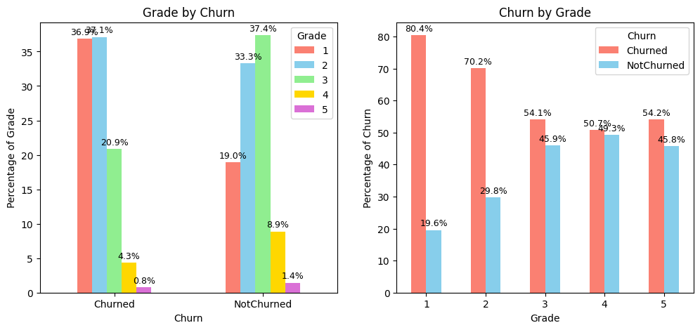

```python
perform_chi_square_test(driversWithCategories,'Churn','Grade')
```

```python
crossNormalized12 = pd.crosstab(driversWithCategories['Churn'], driversWithCategories['Grade'], normalize='columns')
crossNormalized12
```

| Grade Churn | 1 | 2 | 3 | 4 | 5 |
| --- | --- | --- | --- | --- | --- |
| Churned | 0.804318 | 0.701754 | 0.540931 | 0.507246 | 0.541667 |
| NotChurned | 0.195682 | 0.298246 | 0.459069 | 0.492754 | 0.458333 |

Drivers at Grade 1 have a extremely high chance of churn, 80%

Drivers Grade 4 have lowest chance of churning, around 50%, Grade 3.4,5 have overall lower churning chance, around 50-54%

### 3.2.32 Churn and Total Business value

- We established earlier that 161 drivers who have 0 TBV value have substantial income and hence there is chance of missing data there.
- We will ignore those rows and focus on drivers that have non zero total business value and check churn in them
- We already created a dataframe nonZeroTBVDrivers earlier, that we can reuse here for analysis.

```
Ho = Churn and Total Business Value are independent. Medians of groups of Total Business Value based on Churn are same
Ha = Churn and Total Business Value are DEPENDENT. Medians of groups of Total Business Value based on Churn are different
Kruskal-Wallis Result:225.24783639406974,6.482707330521164e-51
Effect Size: η²=0.14
Reject Null Hypothesis. Alternate Hypothesis 'Churn and Total Business Value are DEPENDENT. Medians of groups of Total Business Value based on Churn are different In simple words, there’s substantial Total Business Value difference across Churn values' is True, p-value:0.00.
Churn values vary across Total Business Value groups (enough to be statistically significant kruskal p_value=6.482707330521164e-51), Total Business Value does have a medium influence on Churn (η²=0.14)
```

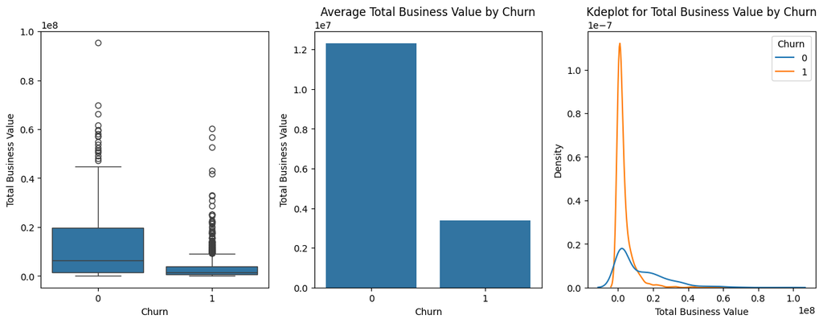

```
   Churn  Total Business Value
0      0          1.230732e+07
1      1          3.382402e+06
```

```python
perform_anova_kruskal(nonZeroTBVDrivers,numerical_column='Total Business Value', categorical_column='Churn', test=test,log="detailed")
```

- The figures are little difficult to read.
- Lets recalculate the mean values with some formatting

```python
nonZeroTBVDrivers.groupby('Churn')['Total Business Value'].mean().apply(lambda x: f"{x:,.0f}")
```

```
Churn
0    12,307,323
1     3,382,402
Name: Total Business Value, dtype: object
```

Drivers who churned have a substantially lower range of total business value

### 3.2.33 Churn and Quarterly Rating

```
Contingency Table:
Quarterly Rating     1    2    3   4
Churn
Churned           1432  146   28  10
NotChurned         312  216  140  97


Chi-square Test Results:
Chi-square statistic: 658.1194
p-value: 0.0000
Degrees of freedom: 3
Significant at α=0.05: Yes
Reject Null Hypothesis. Alternate Hypothesis '<li>Churn and Quarterly Rating are DEPENDENT' is True, p-value:2.528965659451095e-142. However, association is Strong(CramersV=0.53)
```

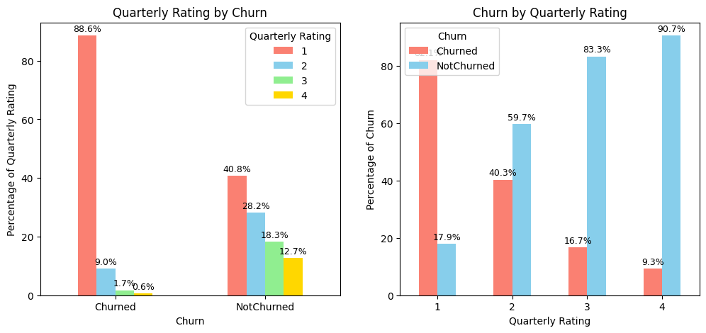

```python
col = 'Quarterly Rating'
perform_chi_square_test(driversWithCategories,'Churn',col)
```

Quarterly rating and Churn are dependent

88% of those who churned had the lowest quarterly rating of 1. It is possible company terminated their services due to the poor rating

Those who have rating greater than 1 have a greater chance of staying

### 3.2.34 Churn and RatingTrend

```
Contingency Table:
RatingTrend  consistent_high  consistent_low  degrading  improving  stable
Churn
Churned                    2            1387         31          5     191
NotChurned                 5             422          0         30     308


Chi-square Test Results:
Chi-square statistic: 330.3970
p-value: 0.0000
Degrees of freedom: 4
Significant at α=0.05: Yes
Reject Null Hypothesis. Alternate Hypothesis '<li>Churn and RatingTrend are DEPENDENT' is True, p-value:2.991165703691902e-70. However, association is Moderate(CramersV=0.37)
```

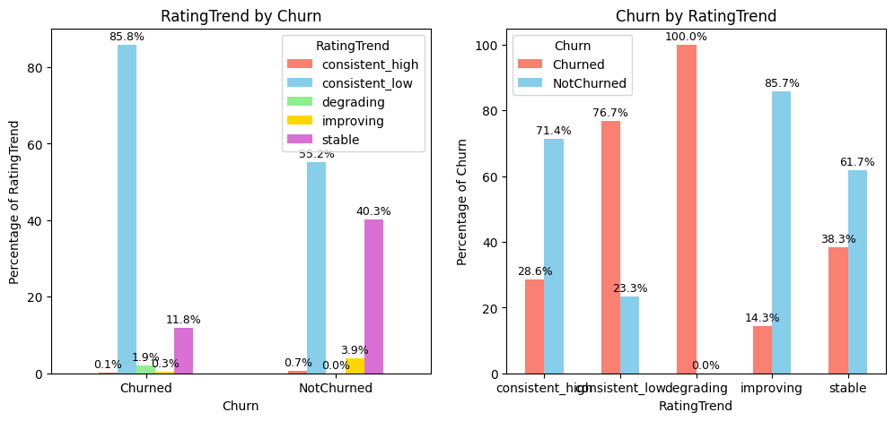

```python
col = 'RatingTrend'
perform_chi_square_test(driversWithCategories,'Churn',col)
```

Rating Trend can help understand churn

Drivers who have consistently high ratings have only 29% of chance of churn

Drivers whose rating has been seen as improving over the months stay with the company 86% of times

ALL drivers whose rating declined were found to have churned.

### 3.2.35 Churn and IncomeIncreased

```
Contingency Table:
IncomeIncreased     0   1
Churn
Churned          1613   3
NotChurned        725  40


Chi-square Test Results:
Chi-square statistic: 71.6474
p-value: 0.0000
Degrees of freedom: 1
Significant at α=0.05: Yes
Reject Null Hypothesis. Alternate Hypothesis '<li>Churn and IncomeIncreased are DEPENDENT' is True, p-value:2.5729990685015372e-17. However, association is Weak(CramersV=0.17)
```

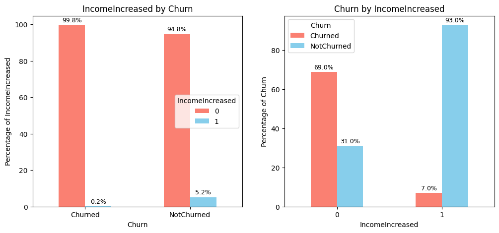

```python
col = 'IncomeIncreased'
perform_chi_square_test(driversWithCategories,'Churn',col)
```

Almost all the drivers who churned did not have a increase in income over the months.

This does not mean that all those who did not see increase in income got churned. That figure is 69%

93% of drivers who saw an increase in income stayed.

### 3.2.36 Churn and GradeIncreased

```
Contingency Table:
GradeIncreased     0    1
Churn
Churned         1395  221
NotChurned       579  186


Chi-square Test Results:
Chi-square statistic: 40.7137
p-value: 0.0000
Degrees of freedom: 1
Significant at α=0.05: Yes
Reject Null Hypothesis. Alternate Hypothesis '<li>Churn and GradeIncreased are DEPENDENT' is True, p-value:1.7624761870029749e-10. However, association is Weak(CramersV=0.13)
```

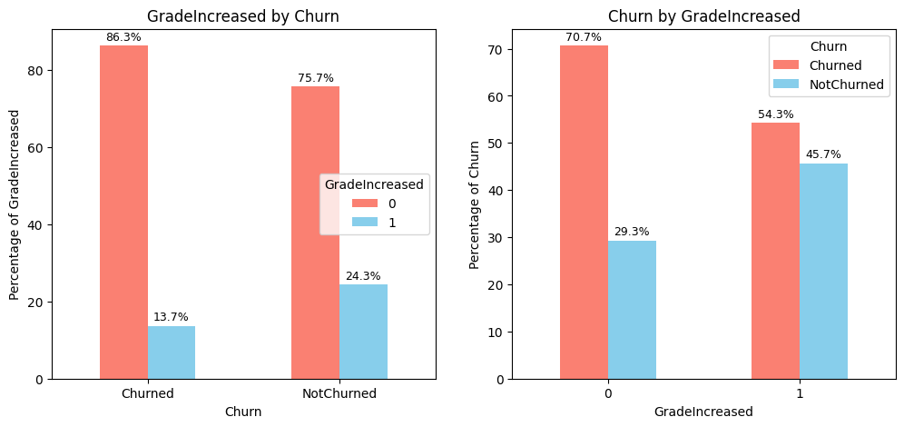

```python
col = 'GradeIncreased'
perform_chi_square_test(driversWithCategories,'Churn',col)
```

Among those whose grade did not increase since joining, 71% left the company

Among those whose grade increased since joining, only 54% left the company

86% of drivers who left the company were those that didnt see increase in their grade since joining

### 3.2.37 City and Education_Level

```
Contingency Table:
City             C1  C10  C11  C12  C13  C14  C15  C16  C17  C18  ...  C27  \
Education_Level                                                   ...
10+              26   32   13   27   24   24   33   31   24   22  ...   31
12+              27   26   25   27   21   30   33   29   22   25  ...   34
Graduate         27   28   26   27   26   25   35   24   25   22  ...   24

City             C28  C29  C3  C4  C5  C6  C7  C8  C9
Education_Level
10+               25   27  26  22  22  32  23  36  22
12+               29   32  25  28  22  23  27  26  28
Graduate          28   37  31  27  36  23  26  27  25

[3 rows x 29 columns]


Chi-square Test Results:
Chi-square statistic: 39.2217
p-value: 0.9567
Degrees of freedom: 56
Significant at α=0.05: No
Fail to Reject Null Hypothesis. Null Hypothesis '<li>Education_Level and City are independent.' is True, p-value:0.9567468072754713
```

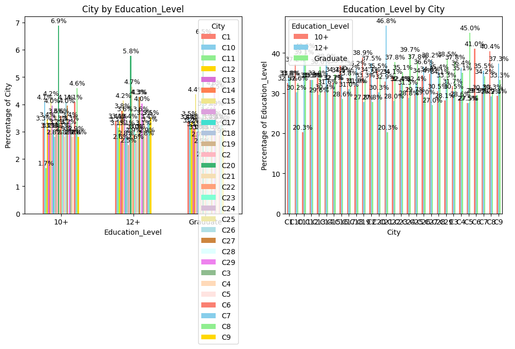

```python
perform_chi_square_test(driversWithCategories,'Education_Level','City')
```

Education Level is similar across cities

### 3.2.38 City and IncomeIncreased

```
Contingency Table:
City             C1  C10  C11  C12  C13  C14  C15  C16  C17  C18  ...  C27  \
IncomeIncreased                                                   ...
0                78   86   63   80   71   76   99   80   71   68  ...   88
1                 2    0    1    1    0    3    2    4    0    1  ...    1

City             C28  C29  C3  C4  C5  C6  C7  C8  C9
IncomeIncreased
0                 79   93  81  76  78  74  75  87  74
1                  3    3   1   1   2   4   1   2   1

[2 rows x 29 columns]


Chi-square Test Results:
Chi-square statistic: 24.0635
p-value: 0.6782
Degrees of freedom: 28
Significant at α=0.05: No
Fail to Reject Null Hypothesis. Null Hypothesis '<li>IncomeIncreased and City are independent.' is True, p-value:0.6781787409841961
```

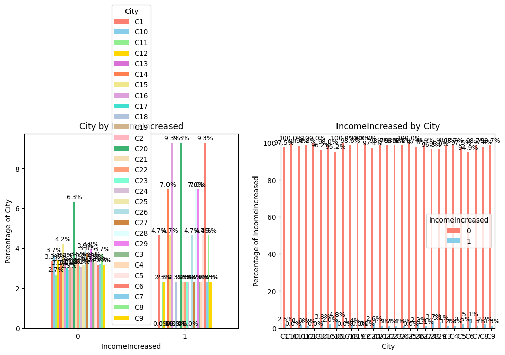

```python
perform_chi_square_test(driversWithCategories,'IncomeIncreased','City')
```

Tendency of income increased is similar across cities

### 3.2.39 City and IncomeLast

```
Ho = City and IncomeLast are independent. Medians of groups of IncomeLast based on City are same
Ha = City and IncomeLast are DEPENDENT. Medians of groups of IncomeLast based on City are different
Kruskal-Wallis Result:28.232537736924705,0.4521771793142992
Effect Size: η²=0.00
Fail to Reject Null Hypothesis. Null Hypothesis 'City and IncomeLast are independent. Medians of groups of IncomeLast based on City are same In simple words, there’s no substantial IncomeLast difference across City values' is True, p-value:0.45
```

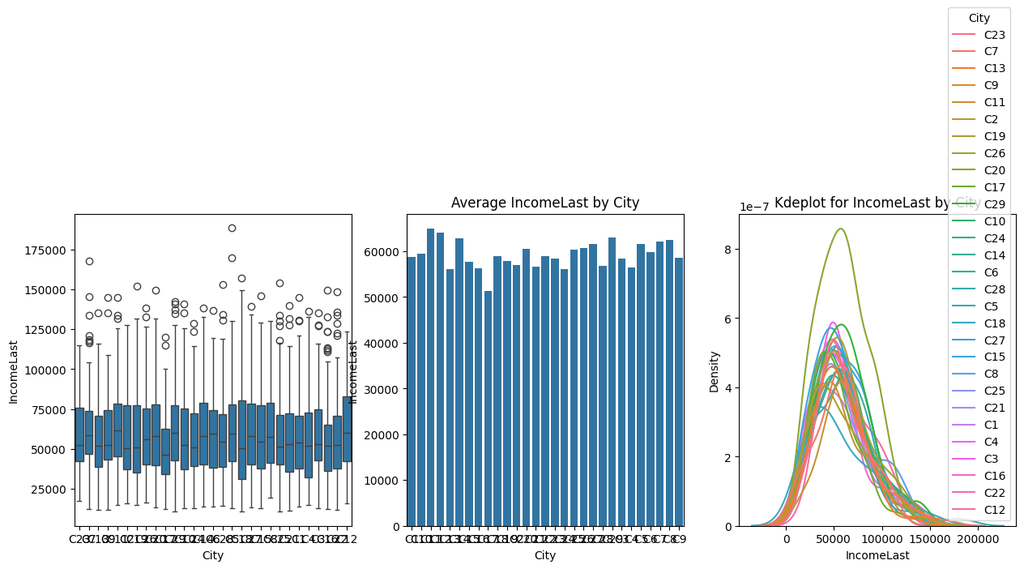

```
   City    IncomeLast
0    C1  58782.762500
1   C10  59421.290698
2   C11  64937.359375
3   C12  64040.209877
4   C13  56022.830986
5   C14  62901.658228
6   C15  57627.504950
7   C16  56318.821429
8   C17  51240.929577
9   C18  59008.521739
10  C19  57823.013889
11   C2  57057.972222
12  C20  60566.164474
13  C21  56597.291139
14  C22  58863.012195
15  C23  58462.797297
16  C24  56165.506849
17  C25  60382.270270
18  C26  60764.107527
19  C27  61669.966292
20  C28  56849.682927
21  C29  62917.093750
22   C3  58352.426829
23   C4  56520.545455
24   C5  61509.975000
25   C6  59886.525641
26   C7  62104.407895
27   C8  62400.573034
28   C9  58624.626667
```

```python
perform_anova_kruskal(drivers,numerical_column='IncomeLast', categorical_column='City', test=test,log="detailed")
```

Income levels are similar across cities

### 3.2.40 City and Total Business Value

We first use the dataframe that contains drivers with zero TBV value

```
Ho = City and Total Business Value are independent. Medians of groups of Total Business Value based on City are same
Ha = City and Total Business Value are DEPENDENT. Medians of groups of Total Business Value based on City are different
Kruskal-Wallis Result:31.575927942560106,0.29210923895603225
Effect Size: η²=0.00
Fail to Reject Null Hypothesis. Null Hypothesis 'City and Total Business Value are independent. Medians of groups of Total Business Value based on City are same In simple words, there’s no substantial Total Business Value difference across City values' is True, p-value:0.29
```

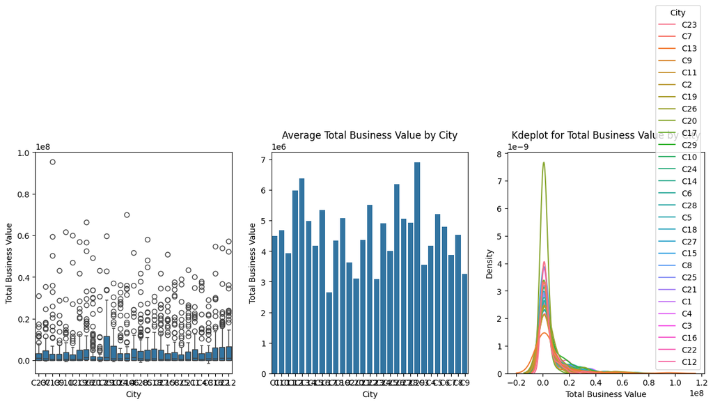

```
   City  Total Business Value
0    C1          4.498329e+06
1   C10          4.678149e+06
2   C11          3.938141e+06
3   C12          5.989065e+06
4   C13          6.381320e+06
5   C14          4.986578e+06
6   C15          4.168672e+06
7   C16          5.339325e+06
8   C17          2.659584e+06
9   C18          4.337070e+06
10  C19          5.074116e+06
11   C2          3.627616e+06
12  C20          3.107131e+06
13  C21          4.371252e+06
14  C22          5.522406e+06
15  C23          3.082497e+06
16  C24          4.917992e+06
17  C25          4.005728e+06
18  C26          6.184266e+06
19  C27          5.051943e+06
20  C28          4.925986e+06
21  C29          6.905977e+06
22   C3          3.557909e+06
23   C4          4.174303e+06
24   C5          5.205819e+06
25   C6          4.789594e+06
26   C7          3.882930e+06
27   C8          4.530628e+06
28   C9          3.244210e+06
```

```python
perform_anova_kruskal(drivers,numerical_column='Total Business Value', categorical_column='City', test=test,log="detailed")
```

- As per this graph, we can conclude that total business value is similar across cities.
- Let us do one more exercise though
- We established earlier that 161 drivers who have 0 TBV value have substantial income and hence there is chance of missing data there.
- We will ignore those rows and focus on drivers that have non zero total business value and check churn in them
- We already created a dataframe nonZeroTBVDrivers earlier, that we can reuse here for analysis.

```
Ho = City and Total Business Value are independent. Medians of groups of Total Business Value based on City are same
Ha = City and Total Business Value are DEPENDENT. Medians of groups of Total Business Value based on City are different
Kruskal-Wallis Result:34.03371501834049,0.199765427507146
Effect Size: η²=0.00
Fail to Reject Null Hypothesis. Null Hypothesis 'City and Total Business Value are independent. Medians of groups of Total Business Value based on City are same In simple words, there’s no substantial Total Business Value difference across City values' is True, p-value:0.20
```

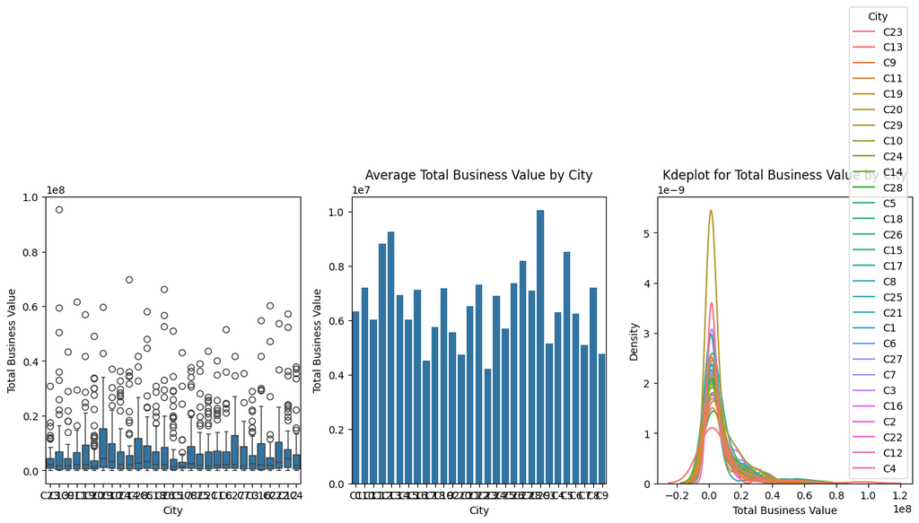

```
   City  Total Business Value
0    C1          6.313444e+06
1   C10          7.193228e+06
2   C11          6.011436e+06
3   C12          8.820259e+06
4   C13          9.246402e+06
5   C14          6.913589e+06
6   C15          6.014799e+06
7   C16          7.119100e+06
8   C17          4.505756e+06
9   C18          5.754958e+06
10  C19          7.163458e+06
11   C2          5.557198e+06
12  C20          4.722839e+06
13  C21          6.515640e+06
14  C22          7.303827e+06
15  C23          4.224427e+06
16  C24          6.904104e+06
17  C25          5.700459e+06
18  C26          7.373548e+06
19  C27          8.174962e+06
20  C28          7.099052e+06
21  C29          1.004506e+07
22   C3          5.142702e+06
23   C4          6.302379e+06
24   C5          8.501275e+06
25   C6          6.226472e+06
26   C7          5.089721e+06
27   C8          7.200463e+06
28   C9          4.770897e+06
```

```python
perform_anova_kruskal(nonZeroTBVDrivers,numerical_column='Total Business Value', categorical_column='City', test=test,log="detailed")
```

As per this graph, we can conclude that total business value is similar across cities.

### 3.2.40 City and Grade

```python
perform_chi_square_test(driversWithCategories,'City','Grade',log="detailed_noplot")
```

```
Contingency Table:
Grade   1   2   3   4  5
City
C1     24  32  16   7  1
C10    30  29  20   7  0
C11    16  28  18   1  1
C12    17  27  29   7  1
C13    23  23  18   5  2
C14    23  29  20   6  1
C15    33  33  28   6  1
C16    32  25  21   4  2
C17    26  28  15   2  0
C18    28  16  21   4  0
C19    22  23  21   5  1
C2     30  17  22   3  0
C20    40  60  42   9  1
C21    25  31  20   2  1
C22    27  29  21   4  1
C23    26  30  14   4  0
C24    25  22  25   1  0
C25    26  27  16   4  1
C26    23  39  23   6  2
C27    21  30  31   7  0
C28    23  34  19   5  1
C29    24  28  32  10  2
C3     32  31  17   2  0
C4     28  22  21   5  1
C5     23  34  20   1  2
C6     27  25  21   4  1
C7     23  30  17   5  1
C8     21  39  20   9  0
C9     23  34  15   3  0


Chi-square Test Results:
Chi-square statistic: 101.4975
p-value: 0.7518
Degrees of freedom: 112
Significant at α=0.05: No
Fail to Reject Null Hypothesis. Null Hypothesis '<li>City and Grade are independent.' is True, p-value:0.7517562728143586
==================================================
```

City and Grade are independent.

### 3.2.41 City and EmploymentAge

```
Ho = City and EmploymentAge are independent. Medians of groups of EmploymentAge based on City are same
Ha = City and EmploymentAge are DEPENDENT. Medians of groups of EmploymentAge based on City are different
Kruskal-Wallis Result:21.750559249733087,0.792706461908808
Effect Size: η²=-0.00
Fail to Reject Null Hypothesis. Null Hypothesis 'City and EmploymentAge are independent. Medians of groups of EmploymentAge based on City are same In simple words, there’s no substantial EmploymentAge difference across City values' is True, p-value:0.79
```

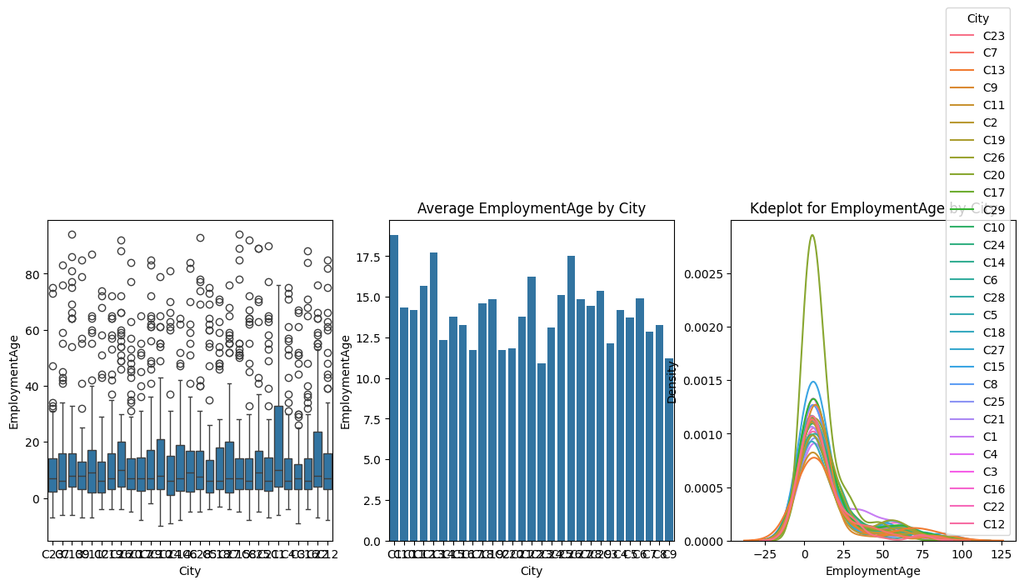

```
   City  EmploymentAge
0    C1      18.800000
1   C10      14.337209
2   C11      14.187500
3   C12      15.654321
4   C13      17.704225
5   C14      12.329114
6   C15      13.792079
7   C16      13.273810
8   C17      11.746479
9   C18      14.608696
10  C19      14.847222
11   C2      11.750000
12  C20      11.809211
13  C21      13.759494
14  C22      16.231707
15  C23      10.891892
16  C24      13.095890
17  C25      15.135135
18  C26      17.526882
19  C27      14.876404
20  C28      14.439024
21  C29      15.385417
22   C3      12.158537
23   C4      14.181818
24   C5      13.737500
25   C6      14.884615
26   C7      12.855263
27   C8      13.280899
28   C9      11.240000
```

```python
perform_anova_kruskal(driversWithCategories,numerical_column='EmploymentAge', categorical_column='City', test=test,log="detailed")
```

EmploymentAge is similar across cities

### 3.2.42 Education_Level and IncomeLast

```
Ho = Education_Level and IncomeLast are independent. Medians of groups of IncomeLast based on Education_Level are same
Ha = Education_Level and IncomeLast are DEPENDENT. Medians of groups of IncomeLast based on Education_Level are different
Kruskal-Wallis Result:51.93343722734432,5.281987790044911e-12
Effect Size: η²=0.02
Reject Null Hypothesis. Alternate Hypothesis 'Education_Level and IncomeLast are DEPENDENT. Medians of groups of IncomeLast based on Education_Level are different In simple words, there’s substantial IncomeLast difference across Education_Level values' is True, p-value:0.00.
Education_Level values vary across IncomeLast groups (enough to be statistically significant kruskal p_value=5.281987790044911e-12), IncomeLast influence on Education_Level is considered small (η²=0.02)
```

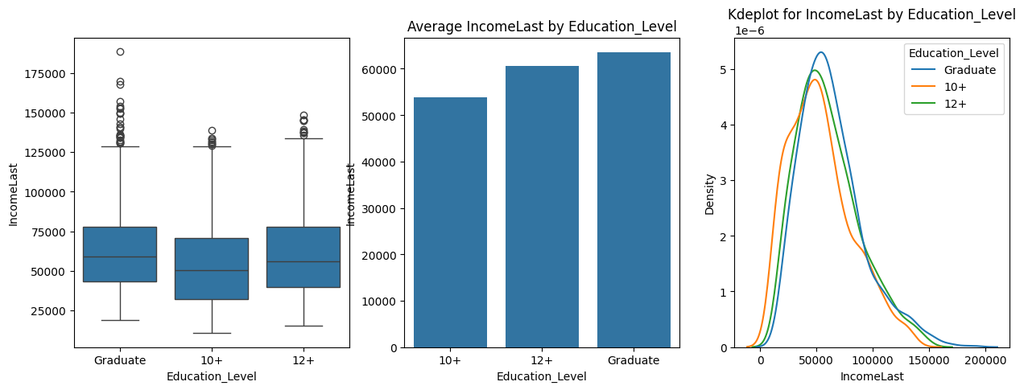

```
  Education_Level    IncomeLast
0             10+  53800.839286
1             12+  60523.885535
2        Graduate  63563.941397
```

```python
perform_anova_kruskal(driversWithCategories,numerical_column='IncomeLast', categorical_column='Education_Level', test=test,log="detailed")
```

Average income varies across education levels- As education level increases, mean income increases

Avg income of Graduates is 63563 which is Rs 10000 more than drivers who are only 10+ education level

### 3.2.43 Education_Level and IncomeIncreased

```
Contingency Table:
IncomeIncreased    0   1
Education_Level
10+              768  16
12+              778  17
Graduate         792  10


Chi-square Test Results:
Chi-square statistic: 2.1528
p-value: 0.3408
Degrees of freedom: 2
Significant at α=0.05: No
Fail to Reject Null Hypothesis. Null Hypothesis '<li>Education_Level and IncomeIncreased are independent.' is True, p-value:0.3408223685733875
```

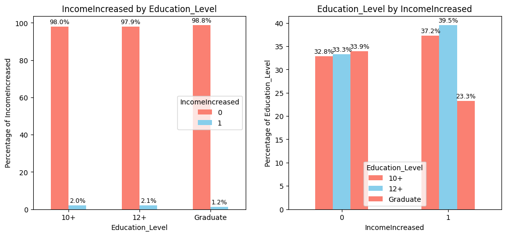

```python
perform_chi_square_test(driversWithCategories,'Education_Level','IncomeIncreased')
```

Income increased is independent of education level

### 3.2.44 Education_Level and GradeIncreased

```
Contingency Table:
GradeIncreased     0    1
Education_Level
10+              650  134
12+              646  149
Graduate         678  124


Chi-square Test Results:
Chi-square statistic: 3.0323
p-value: 0.2196
Degrees of freedom: 2
Significant at α=0.05: No
Fail to Reject Null Hypothesis. Null Hypothesis '<li>Education_Level and GradeIncreased are independent.' is True, p-value:0.21955603862176584
```

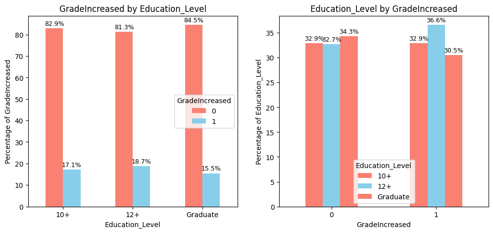

```python
perform_chi_square_test(driversWithCategories,'Education_Level','GradeIncreased')
```

Grade increase and education level are unrelated

### 3.2.44 Education_Level and RatingTrend

```
Contingency Table:
RatingTrend      consistent_high  consistent_low  degrading  improving  stable
Education_Level
10+                            4             624         12         14     130
12+                            1             593         12          9     180
Graduate                       2             592          7         12     189


Chi-square Test Results:
Chi-square statistic: 17.8165
p-value: 0.0226
Degrees of freedom: 8
Significant at α=0.05: Yes
Reject Null Hypothesis. Alternate Hypothesis '<li>Education_Level and RatingTrend are DEPENDENT' is True, p-value:0.022645036466319563. However, association is Negligible(CramersV=0.06)
```

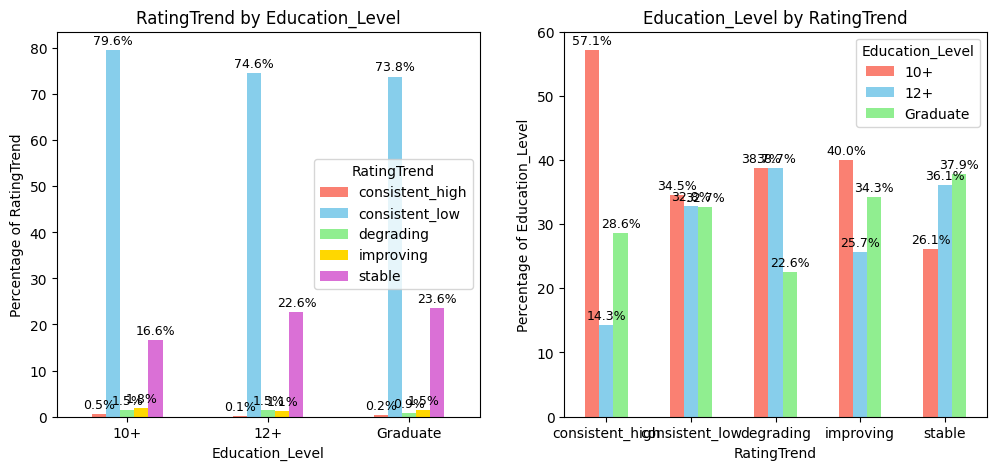

```python
perform_chi_square_test(driversWithCategories,'Education_Level','RatingTrend')
```

```python
driversWithCategories.RatingTrend.value_counts()
```

```
RatingTrend
consistent_low     1809
stable              499
improving            35
degrading            31
consistent_high       7
Name: count, dtype: int64
```

Drivers who have consistently low ratings (1809) are found in all categories equally.

More than half (57%) of the 7 drivers who have consistently high rating are only having 10+ education

# 4.0 Data Preprocessing

- During EDA we grouped the data, engineered many columns and reached the drivers dataframe
- We can use the drivers dataframe for ML Model but it is not how real world works. **- In production / real-world ML pipelines, the data we get is rarely pre-aggregated. **
  - We usually get raw transactional or month-wise data for employees.
  - So our pipeline should be able to take raw data and:
    - Aggregate/group per employee (or per whatever entity you’re predicting for).
    - Apply custom feature engineering (like rating trend, last/first/mean values).
    - Compute derived features (tenure, changes, ratios).
    - Encode categoricals, scale numeric features, and drop unnecessary columns.
    - Feed the result to the model.
  - This way, any new incoming batch of employees can be automatically processed without manual intervention.

**- Why this is better than pre-aggregating**

- If we pre-aggregate before creating a pipeline, our pipeline cannot handle new data
- Hardcoding aggregations or trends outside the pipeline means every time new data arrives, we would have to manually reproduce the same transformations.
- Keeping the aggregation + feature engineering inside the pipeline ensures consistency between train and future inference.

**How it looks conceptually** Our pipeline would roughly do:

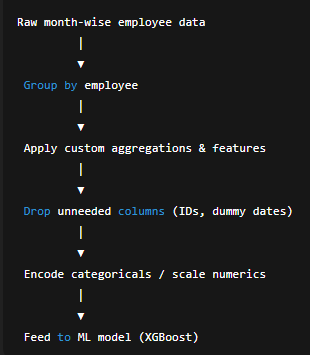

**Implementation notes**

- We will implement custom transformers using sklearn.base.BaseEstimator + TransformerMixin for:
  - Grouping & aggregating
  - Rating trend calculation
  - Tenure computation
- Then use ColumnTransformer + Pipeline to handle numeric/categorical preprocessing and modeling.

For steps like grouping, rating trend, income CAGR, we create custom transformers using sklearn.base.BaseEstimator and TransformerMixin.

```python
import numpy as np
import pandas as pd
from sklearn.base import BaseEstimator, TransformerMixin
from sklearn.impute import KNNImputer, SimpleImputer

class HRChurnFeatureBuilder(BaseEstimator, TransformerMixin):

    def __init__(self, dummy_date="31/12/67"):
        self.dummy_date = dummy_date
        self.average_days_per_month = 365.25/12


    # def transform(self, X):

    def calculateEmploymentAge(self, row):
        if row.Churn==1:
            return np.floor((row.LastWorkingDate - row.Dateofjoining).days/self.average_days_per_month)
        else:
            return np.floor((self.maxDate - row.Dateofjoining).days/self.average_days_per_month)

    def fit(self, X, y=None):
        return self

    def transform(self, X):
        X = X.copy()

        # --- Step 1: Drop unnecessary column ---
        X = X.drop(columns=['Unnamed: 0'], errors='ignore')

        # --- Step 2: Impute Missing Data ---
        imputer = KNNImputer(n_neighbors=1)
        cols_for_impute = ['Age', 'Gender', 'Driver_ID']
        df_impute = X[cols_for_impute].copy()
        df_imputed_values = imputer.fit_transform(df_impute)
        X['Age'] = df_imputed_values[:, 0]
        X['Gender'] = df_imputed_values[:, 1]

        imp_missing = SimpleImputer(strategy='constant', fill_value=self.dummy_date)
        X[['LastWorkingDate']] = imp_missing.fit_transform(X[['LastWorkingDate']])


        # --- Step 3: Parse date columns ---
        X['MMM-YY'] = pd.to_datetime(X['MMM-YY'], format='%m/%d/%y', errors='coerce')
        X['Dateofjoining'] = pd.to_datetime(X['Dateofjoining'], format='%d/%m/%y', errors='coerce')
        X['LastWorkingDate'] = pd.to_datetime(X['LastWorkingDate'], format='%d/%m/%y', errors='coerce')

        self.maxDate = max(X['MMM-YY'])

        # --- Step 4: Group by Driver_ID ---
        grouped = X.groupby('Driver_ID', as_index=False)

        drivers = grouped.agg({
            'Age': 'last',
            'Gender': 'last',
            'City': 'last',
            'Education_Level': 'last',
            'Dateofjoining': 'first',
            'LastWorkingDate': 'last',
            'Joining Designation': 'first',
            'Grade': 'last',
            'Total Business Value': 'sum',
            'Quarterly Rating': 'mean'
        })

        # --- Step 5: Feature Engineering

        # Adding Income CAGR & Last Income ---

        #Aggregate first & last data per driver
        df_sorted = X.sort_values(['Driver_ID', 'MMM-YY'])
        cagr = (
            df_sorted.groupby('Driver_ID', as_index=False)
            .agg(
                IncomeFirst=('Income', 'first'),
                IncomeLast=('Income', 'last'),
                first_date=('MMM-YY', 'first'),
                last_date=('MMM-YY', 'last')
            )
        )
        #Compute time difference in years
        cagr['years'] = (cagr['last_date'] - cagr['first_date']).dt.days / 365
        # Compute CAGR safely
        #Safel because we’ll handle:
        #Drivers with only one record (years == 0)
        #Missing or invalid data (NaN or zero division)
        #If the driver has only one entry → years == 0, we set CAGR = 0.
        cagr['IncomeCAGR'] = np.where(
            cagr['years'] > 0,
            ((cagr['IncomeLast'] / cagr['IncomeFirst']) ** (1 / cagr['years']) - 1) * 100,
            0
        )

        drivers = drivers.merge(cagr[['Driver_ID', 'IncomeLast', 'IncomeCAGR']], on='Driver_ID', how='left')

        # Adding IncomeIncreased
        drivers['IncomeIncreased'] = np.where(drivers['IncomeCAGR'] > 0, 1, 0)

        # Adding GradeIncreased
        drivers['GradeIncreased'] = np.where(drivers['Grade'] > drivers['Joining Designation'], 1, 0)

        # Adding RatingMean, RatingTrend,RatingTrendCode,Ratings
        driver_rating = X.groupby('Driver_ID').apply(classify_driver_rating, include_groups=False).reset_index()
        drivers = drivers.merge(driver_rating, on='Driver_ID', how='left')

        # Adding Churn
        dummyDate = pd.Timestamp('2067-12-31')
        drivers['Churn'] = (drivers['LastWorkingDate'] != dummyDate).astype(int)

        # Adding EmploymentAge
        drivers['EmploymentAge'] = drivers.apply(calculateEmploymentAge, axis=1)

        #Fix negative EmploymentAge (it is coming if LastWorkinDate is less than joinind date, it was present in 130 records in training date)
        #Step 1: Find the rows that has the issue
        driversWithNegativeEmpAge = drivers[drivers.EmploymentAge<0][['Driver_ID']].copy()
        #Count how many records we have for these drivers.  We shall simply put that as the EmploymentAge. It is a fair assumption
        driversWithNegativeEmpAge = driversWithNegativeEmpAge.groupby('Driver_ID', as_index=False).size()
        #Step 2: Merge the counts back and update
        drivers = drivers.merge(
            driversWithNegativeEmpAge.rename(columns={'size': 'EmpAgeFix'}),
            on='Driver_ID',
            how='left'
        )

        # Step 3: Where EmploymentAge was negative, replace with count
        drivers.loc[drivers.EmploymentAge < 0, 'EmploymentAge'] = drivers.loc[drivers.EmploymentAge < 0, 'EmpAgeFix']

        # Step 4: Drop the temporary column
        drivers = drivers.drop(columns=['EmpAgeFix'])

        return drivers
```

```python
from sklearn.preprocessing import OneHotEncoder, RobustScaler, StandardScaler
from category_encoders import TargetEncoder
from sklearn.impute import SimpleImputer
from sklearn.compose import ColumnTransformer
from sklearn.pipeline import Pipeline

# --- Column classification ---
categorical_cols = ['City']  # nominal categorical

# Technical note: One may argue that Gender is not a ordinal column but a nominal one.
# Point taken. Generally we use OHE for such columns
# We have kept Gender here as it already has values 0,1.  Even if we one hot encode it,
# the effect on models is same.
ordinal_cols = [
    'Education_Level', 'Joining Designation', 'Grade',
    'Quarterly Rating', 'IncomeIncreased', 'GradeIncreased', 'RatingTrendCode' ,'Gender'
]  # ordinal / discrete categories

numeric_cols = [
    'Age', 'Total Business Value', 'IncomeLast', 'IncomeCAGR', 'RatingMean', 'EmploymentAge'
]  # continuous numericals

# --- Preprocessing pipelines ---
categorical_transformer = Pipeline([
    ('imputer', SimpleImputer(strategy='most_frequent')),
    # ('encoder', OneHotEncoder(handle_unknown='ignore')),
     ('encoder', TargetEncoder())

])

ordinal_transformer = Pipeline([
    ('imputer', SimpleImputer(strategy='most_frequent'))
    # no scaling or encoding, model can handle integer ordinals directly
])


numeric_transformer = Pipeline([
    ('imputer', SimpleImputer(strategy='median')),
    ('scaler', RobustScaler())  # better for non-normal distributions
    #('scaler', StandardScaler())  #
])

# --- Combine all into one preprocessor ---
preprocessor = ColumnTransformer([
    ('cat', categorical_transformer, categorical_cols),
    ('ord', ordinal_transformer, ordinal_cols),
    ('num', numeric_transformer, numeric_cols),
], remainder='drop')
```

# 5.0 Fitting a Machine Learning Model on the data to predict churn

### 5.1 Prepare the data

#### 5.1.1 Group Data

Here is how the data is being prepared for model

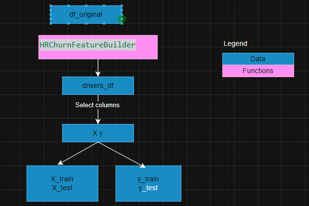

```python
# Step 1 — Feature engineering
df_original =pd.read_csv("ola_driver_scaler.csv")

feature_builder = HRChurnFeatureBuilder(dummy_date="31/12/67")
driver_df = feature_builder.fit_transform(df_original)

driver_df
```

|  | Driver_ID | Age | Gender | City | Education_Level | Dateofjoining | LastWorkingDate | Joining Designation | Grade | Total Business Value | ... | IncomeLast | IncomeCAGR | IncomeIncreased | GradeIncreased | RatingMean | RatingTrend | RatingTrendCode | Ratings | Churn | EmploymentAge |
| --- | --- | --- | --- | --- | --- | --- | --- | --- | --- | --- | --- | --- | --- | --- | --- | --- | --- | --- | --- | --- | --- |
| 0 | 1 | 28.0 | 0.0 | C23 | 2 | 2018-12-24 | 2019-11-03 | 1 | 1 | 1715580 | ... | 57387 | 0.0 | 0 | 0 | 2.000000 | consistent_low | 1 | [[2, 2, 2]] | 1 | 10.0 |
| 1 | 2 | 31.0 | 0.0 | C7 | 2 | 2020-06-11 | 2067-12-31 | 2 | 2 | 0 | ... | 67016 | 0.0 | 0 | 0 | 1.000000 | consistent_low | 1 | [[1, 1]] | 0 | 5.0 |
| 2 | 4 | 43.0 | 0.0 | C13 | 2 | 2019-07-12 | 2020-04-27 | 2 | 2 | 350000 | ... | 65603 | 0.0 | 0 | 0 | 1.000000 | consistent_low | 1 | [[1, 1, 1, 1, 1]] | 1 | 9.0 |
| 3 | 5 | 29.0 | 0.0 | C9 | 0 | 2019-09-01 | 2019-07-03 | 1 | 1 | 120360 | ... | 46368 | 0.0 | 0 | 0 | 1.000000 | consistent_low | 1 | [[1, 1, 1]] | 1 | 1.0 |
| 4 | 6 | 31.0 | 1.0 | C11 | 1 | 2020-07-31 | 2067-12-31 | 3 | 3 | 1265000 | ... | 78728 | 0.0 | 0 | 0 | 1.600000 | consistent_low | 1 | [[1, 1, 2, 2, 2]] | 0 | 4.0 |
| ... | ... | ... | ... | ... | ... | ... | ... | ... | ... | ... | ... | ... | ... | ... | ... | ... | ... | ... | ... | ... | ... |
| 2376 | 2784 | 34.0 | 0.0 | C24 | 0 | 2015-10-15 | 2067-12-31 | 2 | 3 | 21748820 | ... | 82815 | 0.0 | 0 | 1 | 2.625000 | stable | 3 | [[3, 3, 3, 1, 1, 1, 1, 1, 1, 3, 3, 3, 3, 3, 3,... | 0 | 61.0 |
| 2377 | 2785 | 34.0 | 1.0 | C9 | 0 | 2020-08-28 | 2020-10-28 | 1 | 1 | 0 | ... | 12105 | 0.0 | 0 | 0 | 1.000000 | consistent_low | 1 | [[1, 1, 1]] | 1 | 2.0 |
| 2378 | 2786 | 45.0 | 0.0 | C19 | 0 | 2018-07-31 | 2019-09-22 | 2 | 2 | 2815090 | ... | 35370 | 0.0 | 0 | 0 | 1.666667 | consistent_low | 1 | [[2, 2, 2, 2, 2, 2, 1, 1, 1]] | 1 | 13.0 |
| 2379 | 2787 | 28.0 | 1.0 | C20 | 2 | 2018-07-21 | 2019-06-20 | 1 | 1 | 977830 | ... | 69498 | 0.0 | 0 | 0 | 1.500000 | consistent_low | 1 | [[2, 2, 2, 1, 1, 1]] | 1 | 10.0 |
| 2380 | 2788 | 30.0 | 0.0 | C27 | 2 | 2020-08-06 | 2067-12-31 | 2 | 2 | 2298240 | ... | 70254 | 0.0 | 0 | 0 | 2.285714 | stable | 3 | [[1, 3, 3, 3, 2, 2, 2]] | 0 | 3.0 |

2381 rows × 21 columns

#### 5.1.2 Train Test Split

```python
# Keep a copy for later join-back
driver_ids = driver_df['Driver_ID']

# Split into features (X) and label (y)
#We drop few columns that we dont need for training model, and we have derived some other features from them
#We drop Churn as it is target column
X = driver_df.drop(columns=['Driver_ID','Dateofjoining', 'LastWorkingDate','Ratings','RatingTrend','Churn'])
y = driver_df['Churn']

#
# Train-test split
from sklearn.model_selection import train_test_split
X_train, X_test, y_train, y_test = train_test_split(
    X, y, test_size=0.2, random_state=42, stratify=y
)
```

```python
X_train
```

|  | Age | Gender | City | Education_Level | Joining Designation | Grade | Total Business Value | Quarterly Rating | IncomeLast | IncomeCAGR | IncomeIncreased | GradeIncreased | RatingMean | RatingTrendCode | EmploymentAge |
| --- | --- | --- | --- | --- | --- | --- | --- | --- | --- | --- | --- | --- | --- | --- | --- |
| 2242 | 34.0 | 1.0 | C7 | 0 | 3 | 3 | 0 | 1.000000 | 104058 | 0.0 | 0 | 0 | 1.000000 | 1 | 5.0 |
| 1474 | 42.0 | 0.0 | C9 | 0 | 1 | 1 | 0 | 1.000000 | 51579 | 0.0 | 0 | 0 | 1.000000 | 1 | 17.0 |
| 2132 | 27.0 | 0.0 | C17 | 1 | 2 | 2 | 0 | 1.000000 | 75458 | 0.0 | 0 | 0 | 1.000000 | 1 | 2.0 |
| 1873 | 35.0 | 0.0 | C15 | 1 | 1 | 3 | 29040450 | 3.000000 | 69756 | 0.0 | 0 | 1 | 3.000000 | 3 | 53.0 |
| 462 | 36.0 | 0.0 | C24 | 0 | 2 | 3 | 0 | 1.000000 | 109296 | 0.0 | 0 | 1 | 1.000000 | 1 | 30.0 |
| ... | ... | ... | ... | ... | ... | ... | ... | ... | ... | ... | ... | ... | ... | ... | ... |
| 1883 | 39.0 | 0.0 | C26 | 1 | 1 | 4 | 66352800 | 3.285714 | 112513 | 0.0 | 0 | 1 | 3.285714 | 3 | 20.0 |
| 1355 | 27.0 | 0.0 | C28 | 0 | 2 | 2 | 0 | 1.000000 | 49886 | 0.0 | 0 | 0 | 1.000000 | 1 | 1.0 |
| 2229 | 39.0 | 0.0 | C29 | 1 | 1 | 1 | 2607050 | 2.000000 | 44154 | 0.0 | 0 | 0 | 2.000000 | 1 | 3.0 |
| 2234 | 28.0 | 0.0 | C16 | 1 | 1 | 1 | 2264270 | 1.272727 | 53320 | 0.0 | 0 | 0 | 1.272727 | 1 | 6.0 |
| 855 | 30.0 | 1.0 | C8 | 0 | 1 | 1 | 0 | 1.000000 | 58540 | 0.0 | 0 | 0 | 1.000000 | 1 | 4.0 |

1904 rows × 15 columns

## 5.2 Quick Checks on data - PCA to see separatability, VIF to see collinearity

### 5.2.1 Access the preproceesor output and use PCA to quickly visualize data

```
Explained variance ratio: [0.5631135  0.12596309]
```

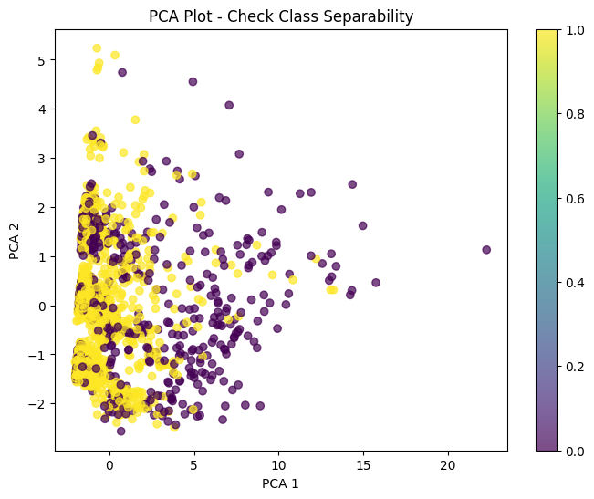

```python
from sklearn.decomposition import PCA

#Create a pipeline with just the preprocessor
pipeline_to_get_input_data  = Pipeline([
    ('preprocess', preprocessor),
])
pipeline_to_get_input_data.fit(X_train, y_train)


# Access the fitted preprocessor
X_train_transformed = pipeline_to_get_input_data.named_steps['preprocess'].transform(X_train)

X_train_scaled = pd.DataFrame(X_train_transformed, columns=categorical_cols+ ordinal_cols+ numeric_cols)

#X_scaled is a dataframe that has the correct column names and all features in numerical format.
X_train_scaled.head()


pca = PCA(n_components=2)
X_pca = pca.fit_transform(X_train_scaled)

print("Explained variance ratio:", pca.explained_variance_ratio_)

# Plot
plt.figure(figsize=(8,6))
scatter = plt.scatter(X_pca[:,0], X_pca[:,1], c=y_train, alpha=0.7)
plt.xlabel("PCA 1")
plt.ylabel("PCA 2")
plt.title("PCA Plot - Check Class Separability")
plt.colorbar(scatter)
plt.show()
```

### 5.2.2 Use PCA to compress to 3 dimensions, where we can rotate as well

```python
import plotly.express as px
from sklearn.decomposition import PCA

# PCA 3 components
pca = PCA(n_components=3)
X_pca = pca.fit_transform(X_train_scaled)
print("Explained variance ratio:", pca.explained_variance_ratio_)

# Convert to DataFrame
df_pca = pd.DataFrame({
    'PCA1': X_pca[:,0],
    'PCA2': X_pca[:,1],
    'PCA3': X_pca[:,2],
    'Target': y_train
})

# Interactive plot
fig = px.scatter_3d(
    df_pca,
    x='PCA1',
    y='PCA2',
    z='PCA3',
    color='Target',
    opacity=0.8,
    width=900,
    height=700
)

fig.update_traces(marker=dict(size=4))
fig.show()
```

[output not shown]

```
Explained variance ratio: [0.5631135  0.12596309 0.0835692 ]
```

Approximate linear separability Not clearly linear — notable overlap in PCA1–PCA2 and PCA1–PCA3 projections.

Need for nonlinear interaction capture- PCA shows curved “frontier”-like mixing; not a straight split. Suggests relationships among predictors might be multiplicative or nonlinear.

### 5.2.3 Feature Selection using VIF score checking for Multicollinearity

Lets calculate VIF once, to see what we have on hand - do we even need to check rigourously

```python
from statsmodels.stats.outliers_influence import variance_inflation_factor
vif = pd.DataFrame()
vif['Features'] = X_train_scaled.columns
vif['VIF'] = [variance_inflation_factor(X_train_scaled.values, i) for i in range(X_train_scaled.shape[1])]
vif_sorted = vif.sort_values(by='VIF', ascending=False)
vif_sorted
```

|  | Features | VIF |
| --- | --- | --- |
| 4 | Quarterly Rating | 356.875310 |
| 13 | RatingMean | 105.705042 |
| 5 | IncomeIncreased | 14.464880 |
| 12 | IncomeCAGR | 14.258356 |
| 3 | Grade | 13.893484 |
| 2 | Joining Designation | 10.704713 |
| 6 | GradeIncreased | 5.915194 |
| 7 | RatingTrendCode | 3.783199 |
| 10 | Total Business Value | 3.694568 |
| 14 | EmploymentAge | 2.897253 |
| 11 | IncomeLast | 2.369469 |
| 9 | Age | 1.160679 |
| 1 | Education_Level | 1.059439 |
| 0 | City | 1.016781 |
| 8 | Gender | 1.009353 |

Indeed, it seems we have lot of columns that are collinear. We have our work cutout.  
We will calculate VIF recursively till we have no columns with high VIF

```python
def calculate_vif(X, thresh=10.0):
    """
    Iteratively remove features with VIF above the specified threshold.

    Parameters:
        X (pd.DataFrame): Scaled numeric feature DataFrame
        thresh (float): VIF threshold, e.g. 10.0

    Returns:
        pd.DataFrame: Final VIF values for remaining features
        list: Names of features that were removed
    """

    variables = X.columns.tolist()
    dropped = True
    removed_features = []

    while dropped:
        dropped = False
        vif = pd.DataFrame()
        vif['Features'] = variables
        vif['VIF'] = [variance_inflation_factor(X[variables].values, i)
                      for i in range(len(variables))]

        max_vif = vif['VIF'].max()
        if max_vif > thresh:
            # Feature with the highest VIF
            feature_to_drop = vif.loc[vif['VIF'].idxmax(), 'Features']

            print(f"We can drop '{feature_to_drop}' as its VIF is ={max_vif:.2f}")

            variables.remove(feature_to_drop)
            removed_features.append(feature_to_drop)
            dropped = True

    # Compute final VIFs for remaining features
    final_vif = pd.DataFrame()
    final_vif['Features'] = variables
    final_vif['VIF'] = [variance_inflation_factor(X[variables].values, i)
                        for i in range(len(variables))]

    # Sort for readability
    final_vif = final_vif.sort_values(by='VIF', ascending=False).reset_index(drop=True)
    return final_vif, removed_features

final_vif, columns_to_drop = calculate_vif(X_train_scaled, thresh=10)
print("\nFinal VIF values:")
print(final_vif)

print("\nRemovable features:",len(columns_to_drop))
print(columns_to_drop)
```

```
We can drop 'Quarterly Rating' as its VIF is =356.88
We can drop 'Grade' as its VIF is =82.49
We can drop 'City' as its VIF is =16.12
We can drop 'IncomeIncreased' as its VIF is =14.47
We can drop 'RatingTrendCode' as its VIF is =11.80

Final VIF values:
               Features       VIF
0  Total Business Value  3.564701
1         EmploymentAge  3.301733
2            RatingMean  3.083065
3        GradeIncreased  2.904099
4   Joining Designation  2.682852
5       Education_Level  2.182359
6                Gender  1.599849
7            IncomeLast  1.409092
8            IncomeCAGR  1.284353
9                   Age  1.146486

Removable features: 5
['Quarterly Rating', 'Grade', 'City', 'IncomeIncreased', 'RatingTrendCode']
```

- Lets model the dropping of these columns as a transformer.
- We can use it if required, by adding it in pipeline, just before we feed the data into the Model

```python
import pandas as pd


class ColumnDropper(BaseEstimator, TransformerMixin):
    """
    Drops specified columns from a NumPy array (output of preprocessor),
    using known column names from preprocessor.get_feature_names_out().
    """
    def __init__(self, drop_cols=None, all_feature_names=None, return_df=False):
        self.drop_cols = drop_cols or []
        self.all_feature_names = all_feature_names  # column names from preprocessor
        self.return_df = return_df  # optional: return a DataFrame if desired

    def fit(self, X, y=None):
        # Nothing to learn, just store column info
        return self

    def transform(self, X):
        # Make sure we have column names
        if self.all_feature_names is None:
            raise ValueError("all_feature_names must be provided for ColumnDropper.")

        # Convert numpy → DataFrame with the feature names
        df = pd.DataFrame(X, columns=self.all_feature_names)

        # Drop the specified columns
        df_filtered = df.drop(columns=self.drop_cols, errors='ignore')

        #print(f'[{self.__class__.__name__}]- Collinear columns were dropped')
        # Return DataFrame or NumPy depending on configuration
        if self.return_df:
            return df_filtered
        else:
            return df_filtered.to_numpy()
```

## 5.3 Fitting ALL models without hyperparam tuning, VIF and imbalance fix

```python
from sklearn.pipeline import Pipeline
from sklearn.ensemble import RandomForestClassifier
from sklearn.ensemble import GradientBoostingClassifier
from sklearn.linear_model import LogisticRegression
from lightgbm import LGBMClassifier
from xgboost import XGBClassifier
from sklearn.naive_bayes import GaussianNB
```

Program Flow

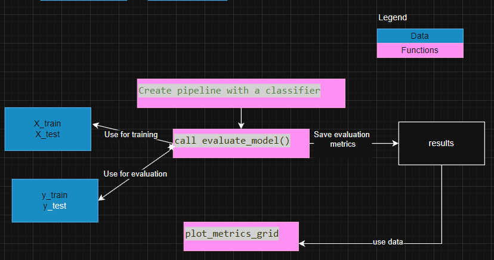

### Lets create reusable code to build the model and store results

- Builds pipeline,
- trains the model,
- calculates metrics,
- saves results, and
- returns trained model.

```python
### Code to plot the results

import matplotlib.pyplot as plt
import numpy as np
import math

def plot_metrics_grid(results, metrics,  selectedModels='ALL',pad_ratio=0.05,):
    """
    Multi-axis figure with:
    - 2 columns grid layout (rows auto-calculated)
    - Each subplot: bar chart for one metric
    - One consistent color per model EXCEPT the highest bar per subplot → GREEN
    - Model names on x-axis
    - Legend for models
    - Zoomed y-axis
    - Value labels on bars

    -selected_model_ids - can be a list of values or a search string with multiple search values.
        - pass the ids of selected models as an list, default is all models. Eg [2,6,10]
        - pass a search string - Logistic, Random

    """
    global tableNumber
    #Filter selected models
    if (selectedModels!='ALL'):
        #User has passed a list
        if isinstance(selectedModels,list):
            results = results.iloc[selected_model_ids]
        elif isinstance(selectedModels,object):
            filters = [x.strip() for x in selectedModels.split(",")]
            pattern = "|".join(filters)
            results = results[
                results["Model"].str.contains(pattern, case=False, regex=True)
            ]
    num_metrics = len(metrics)
    num_models = len(results)
    #append the ModelID for easier identification when we have large number of models
    models = (results["ModelID"].astype(str) + "." + results["Model"]).tolist()


    # --- Layout: always 2 columns ---
    cols = 2
    rows = math.ceil(num_metrics / 2)

    fig, axes = plt.subplots(rows, cols, figsize=(15, 4 * rows))
    axes = axes.flatten()

    # --- Base color palette for models ---
    # cmap = plt.cm.get_cmap("tab10", num_models)
    # base_colors = [cmap(i) for i in range(num_models)]
    base_colors = ["grey" for i in range(num_models)]


    for i, metric in enumerate(metrics):
        ax = axes[i]
        values = results[metric].values
        x = np.arange(num_models)

        # Identify max bar → will be GREEN
        max_index = np.argmax(values)

        # Colors for this subplot: model colors, except max = green
        colors = base_colors.copy()
        colors[max_index] = "green"

        # Plot
        bars = ax.bar(x, values, color=colors, edgecolor='black')

        # Title / Labels
        ax.set_title(f'Table {tableNumber}. {metric}', fontsize=14)
        tableNumber+=1 #increment always
        ax.set_xticks(x)
        ax.set_xticklabels(models, rotation=45, ha='right')
        ax.set_ylabel(metric)

        # Auto-zoom y-axis
        ymin, ymax = values.min(), values.max()
        pad = (ymax - ymin) * pad_ratio if ymax > ymin else 0.01
        ax.set_ylim(ymin - pad, ymax + pad)

        # Bar labels
        for bar in bars:
            h = bar.get_height()
            ax.text(
                bar.get_x() + bar.get_width() / 2,
                h,
                f"{h:.4f}",
                ha='center',
                va='bottom',
                fontsize=9
            )

    # # Legend for models (global)
    # fig.legend(
    #     labels=models,
    #     loc='upper center',
    #     ncol=min(num_models, 4),
    #     fontsize=12,
    #     frameon=False
    # )

    # Hide extra axes if odd number of metrics
    for j in range(num_metrics, len(axes)):
        axes[j].axis("off")

    plt.tight_layout(rect=[0, 0, 1, 0.95])
    plt.show()


    print((results[["Model","TestF2Score"]].sort_values(by="TestF2Score", ascending=False)))
```

```python
import time
import numpy as np
from sklearn.metrics import (
    accuracy_score, f1_score, fbeta_score,
    precision_score, recall_score
)
from sklearn.model_selection import StratifiedKFold
from sklearn.base import clone
from sklearn.utils.validation import check_is_fitted
from sklearn.exceptions import NotFittedError

def is_model_trained(model):
    try:
        check_is_fitted(model)
        return True
    except NotFittedError:
        return False

def evaluate_model(model_id, model_name, model,
                   X_train, X_test, y_train, y_test,
                   folds=5):
    """
    Use Stratified K-Fold CV on training data.
    Calculate mean metrics across folds.
    Train final model on full training set.
    Evaluate on test set.
    Save result row.
    """
    skf = StratifiedKFold(n_splits=folds, shuffle=True, random_state=42)
    # Deep copy of pipeline
    untrained_pipeline = clone(model)

    # Lists to collect per-fold metrics
    train_acc_list, val_acc_list = [], []
    train_f1_list,  val_f1_list  = [], []
    train_f2_list,  val_f2_list  = [], []
    train_prec_list, val_prec_list = [], []
    train_rec_list,  val_rec_list  = [], []

    # --- Cross-validation ---
    for train_idx, val_idx in skf.split(X_train, y_train):
        X_tr, X_val = X_train.iloc[train_idx], X_train.iloc[val_idx]
        y_tr, y_val = y_train.iloc[train_idx], y_train.iloc[val_idx]

        # Fit on training fold
        # We only fit if the model is not already trained
        if not is_model_trained(model):
            model.fit(X_tr, y_tr)

        # Predictions
        y_pred_tr = model.predict(X_tr)
        y_pred_val = model.predict(X_val)

        # Per-fold metrics
        train_acc_list.append(accuracy_score(y_tr, y_pred_tr))
        val_acc_list.append(accuracy_score(y_val, y_pred_val))

        train_f1_list.append(f1_score(y_tr, y_pred_tr))
        val_f1_list.append(f1_score(y_val, y_pred_val))

        train_f2_list.append(fbeta_score(y_tr, y_pred_tr, beta=2))
        val_f2_list.append(fbeta_score(y_val, y_pred_val, beta=2))

        train_prec_list.append(precision_score(y_tr, y_pred_tr))
        val_prec_list.append(precision_score(y_val, y_pred_val))

        train_rec_list.append(recall_score(y_tr, y_pred_tr))
        val_rec_list.append(recall_score(y_val, y_pred_val))

    # Mean metrics across folds
    train_acc  = np.mean(train_acc_list)
    val_acc    = np.mean(val_acc_list)

    train_f1   = np.mean(train_f1_list)
    val_f1     = np.mean(val_f1_list)

    train_f2   = np.mean(train_f2_list)
    val_f2     = np.mean(val_f2_list)
    val_f2_std = np.std(val_f2_list)

    train_prec = np.mean(train_prec_list)
    val_prec   = np.mean(val_prec_list)

    train_rec  = np.mean(train_rec_list)
    val_rec    = np.mean(val_rec_list)

    # ---- Train final model on full training data ----
    start = time.time()
    model.fit(X_train, y_train)
    train_time = time.time() - start

# ---- Evaluate on test ----
    y_pred_test = model.predict(X_test)
    test_acc  = accuracy_score(y_test, y_pred_test)
    test_f1   = f1_score(y_test, y_pred_test)
    test_f2   = fbeta_score(y_test, y_pred_test, beta=2)
    test_prec = precision_score(y_test, y_pred_test)
    test_rec  = recall_score(y_test, y_pred_test)

    # Hyperparameters of classifier part of pipeline
    hyperparams = model.named_steps['clf'].get_params()


    # ---- Store results ----
    global results
    results.loc[len(results)] = [
        model_id, model_name, hyperparams,
        train_acc, val_acc, test_acc,
        train_f1, val_f1, test_f1,
        train_f2, val_f2, val_f2_std, test_f2,
        train_prec, val_prec, test_prec,
        train_rec, val_rec, test_rec,
        train_time
    ]

    #We return untrained pipeline and trained model
    #Untrained pipeline is useful if we want to retrain teh model on a different set of data
    #Eg we utilise it during threshold tuning.
    return (untrained_pipeline,model)
```

```python
#These are GLOBAL variables used in this code.

# Global variable that stores the models we created.  It keeps getting appeneded with more and more models
models=[]

# Global variable that stores results from various model evaluation
# We calculate F2 score too, as we want to prioritize recall over precision.
results = pd.DataFrame(columns=[
    'ModelID',
    'Model',
    'Hyperparameters',

    'TrainAccuracy',
    'ValAccuracy',
    'TestAccuracy',

    'TrainF1Score',
    'ValF1Score',
    'TestF1Score',

    'TrainF2Score',
    'ValF2Score',
    'ValF2ScoreStd',#To Check CV Stability for F2 Score
    'TestF2Score',

    'TrainPrecision',
    'ValPrecision',
    'TestPrecision',

    'TrainRecall',
    'ValRecall',
    'TestRecall',


    'TrainingTime'
])


# Global variable that stores table numbers.  It keeps getting incremented every time we draw an axes
tableNumber=1
```

### Fitting Logistic

```python
#Create pipeline with a classifier
pipeline = Pipeline(steps=[
    ('preprocess', preprocessor),
    ('clf', LogisticRegression(random_state=42))  # 4️⃣ Example model

  ])

trained_model = evaluate_model(len(models),"Logistic Untuned Imbalanced",pipeline, X_train, X_test, y_train, y_test)
models.append(trained_model)
```

### Fitting Random Forest

```python
######################
pipeline  = Pipeline([
    ('preprocess', preprocessor),
    ('clf', RandomForestClassifier(random_state=42))
])

trained_model = evaluate_model(len(models),
                               "RandomForest Untuned Imbalanced",
                                pipeline,
                                X_train, X_test, y_train, y_test
                            )
models.append(trained_model)
```

### Fitting GBM

```python
######################
pipeline  = Pipeline([
    ('preprocess', preprocessor),
    ('clf', GradientBoostingClassifier(n_estimators=200, max_depth=2, loss = 'log_loss'))
])

trained_model = evaluate_model(len(models),
                               "GradientBoosting Untuned Imbalanced",
                                pipeline,
                                X_train, X_test, y_train, y_test
                            )
models.append(trained_model)
```

### Fitting XGBoost

```python
######################
pipeline  = Pipeline([
    ('preprocess', preprocessor),
    ('clf', XGBClassifier(random_state=10))
])

trained_model = evaluate_model(len(models),
                               "XGBoost Untuned Imbalanced",
                                pipeline,
                                X_train, X_test, y_train, y_test
                            )
models.append(trained_model)
```

### Fitting LGBM

```python
######################
pipeline  = Pipeline([
    ('preprocess', preprocessor),
    ('clf', LGBMClassifier(random_state=42))
])

trained_model = evaluate_model(len(models),
                               "LightGBM Untuned Imbalanced",
                                pipeline,
                                X_train, X_test, y_train, y_test
                            )
models.append(trained_model)
```

[output not shown]

```python
results
```

|  | ModelID | Model | Hyperparameters | TrainAccuracy | ValAccuracy | TestAccuracy | TrainF1Score | ValF1Score | TestF1Score | TrainF2Score | ValF2Score | ValF2ScoreStd | TestF2Score | TrainPrecision | ValPrecision | TestPrecision | TrainRecall | ValRecall | TestRecall | TrainingTime |
| --- | --- | --- | --- | --- | --- | --- | --- | --- | --- | --- | --- | --- | --- | --- | --- | --- | --- | --- | --- | --- |
| 0 | 0 | Logistic Untuned Imbalanced | {'C': 1.0, 'class_weight': None, 'dual': False... | 0.762080 | 0.762078 | 0.779874 | 0.842654 | 0.842659 | 0.851485 | 0.897853 | 0.897841 | 0.009638 | 0.896367 | 0.764338 | 0.764384 | 0.785901 | 0.938853 | 0.938838 | 0.929012 | 0.029001 |
| 1 | 1 | RandomForest Untuned Imbalanced | {'bootstrap': True, 'ccp_alpha': 0.0, 'class_w... | 0.953783 | 0.953806 | 0.796646 | 0.966524 | 0.968116 | 0.858806 | 0.974479 | 0.974962 | 0.050075 | 0.889090 | 0.953623 | 0.957823 | 0.812672 | 0.979874 | 0.979845 | 0.910494 | 0.247996 |
| 2 | 2 | GradientBoosting Untuned Imbalanced | {'ccp_alpha': 0.0, 'criterion': 'friedman_mse'... | 0.824580 | 0.824577 | 0.794549 | 0.879862 | 0.879947 | 0.858382 | 0.918720 | 0.918713 | 0.016521 | 0.892428 | 0.821936 | 0.822348 | 0.807065 | 0.946594 | 0.946595 | 0.916667 | 0.385000 |
| 3 | 3 | XGBoost Untuned Imbalanced | {'objective': 'binary:logistic', 'base_score':... | 0.946430 | 0.946457 | 0.788260 | 0.960805 | 0.961342 | 0.849028 | 0.964341 | 0.964514 | 0.069436 | 0.865326 | 0.954977 | 0.956200 | 0.823188 | 0.966715 | 0.966667 | 0.876543 | 0.063998 |
| 4 | 4 | LightGBM Untuned Imbalanced | {'boosting_type': 'gbdt', 'class_weight': None... | 0.930674 | 0.930696 | 0.792453 | 0.950026 | 0.950407 | 0.853333 | 0.962255 | 0.962377 | 0.057230 | 0.874317 | 0.930326 | 0.931181 | 0.820513 | 0.970586 | 0.970549 | 0.888889 | 0.062111 |

### Discussion: What metrics are most important for us

- In Employee Churn Use Case → RECALL Is More Important
  - **Why? **Because Missing a true churner (false negative) is costly:
    - loss of skilled employee
    - cost of hiring + training
    - loss of productivity
    - loss of domain knowledge
  - Therefore, Organizations want to identify as many at-risk employees as possible, even if it means some false alarms.
  - Even if some employees are flagged incorrectly (false positives), it’s usually okay because:
    - the intervention cost is low (discussion, survey, manager 1-on-1)
    - the cost of losing an employee is very high
  - For F-score we will also calculate F2 Score apart from F1 score
    - As recall matters more → F2 score gives a better metric (weights recall 2×)

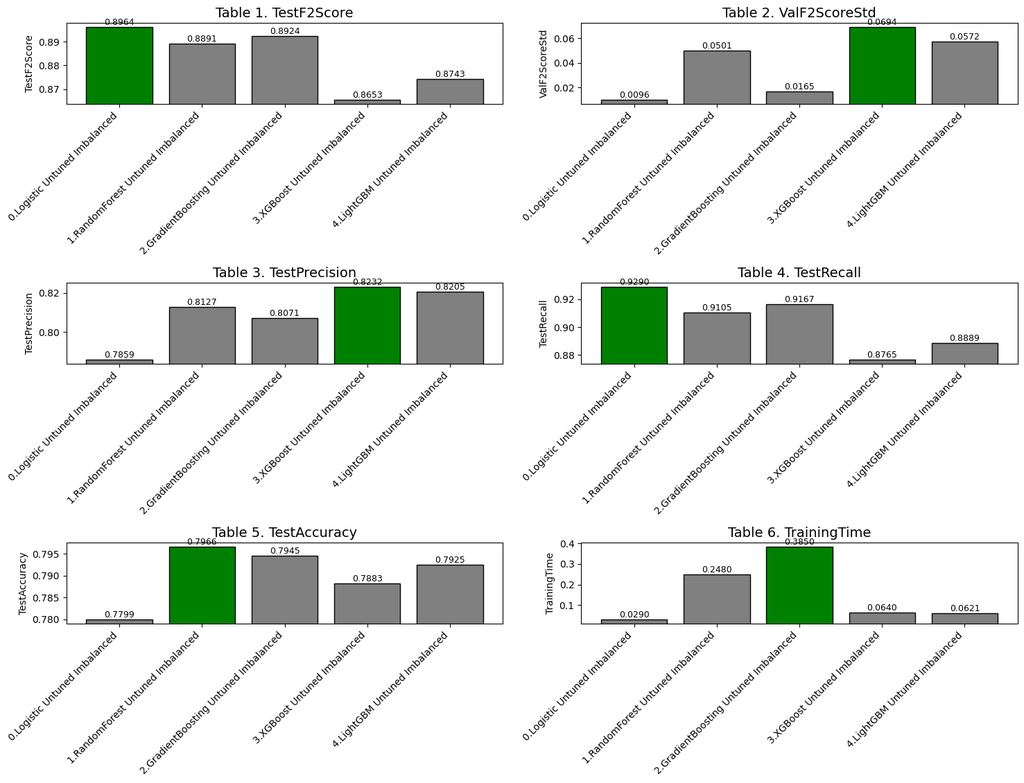

```
                                 Model  TestF2Score
0          Logistic Untuned Imbalanced     0.896367
2  GradientBoosting Untuned Imbalanced     0.892428
1      RandomForest Untuned Imbalanced     0.889090
4          LightGBM Untuned Imbalanced     0.874317
3           XGBoost Untuned Imbalanced     0.865326
```

```python
metrics_to_plot = [
    'TestF2Score',
    'ValF2ScoreStd',
    'TestPrecision',
    'TestRecall',
    'TestAccuracy',
    'TrainingTime'
]

plot_metrics_grid(results, metrics_to_plot)
```

Logistic Untuned Imbalanced has best F2 score (0.896), that prioritizes recall. It has best recall too of 0.929

Random Forest Untuned Imbalanced has best F1 score (0.8588)

## 5.4 Lets handle class imbalance

- We already established we have imbalanced data. So lets fix it and see if it improves results.
- We can use **SMOTE** and **class_weight='balanced'** whereever supported.
  - ⭐ For Logistic Regression
  - → Use class_weight='balanced'
  - (logistic + SMOTE hurts due to over-smoothing)
  - ⭐ For Random Forest & XGBoost
  - → SMOTE performs better in most real-world cases
  - (because synthetic samples create better-defined split regions)

  ⭐ For GradientBoostingClassifier
  - → Does not support class weights
  - → SMOTE helps significantly

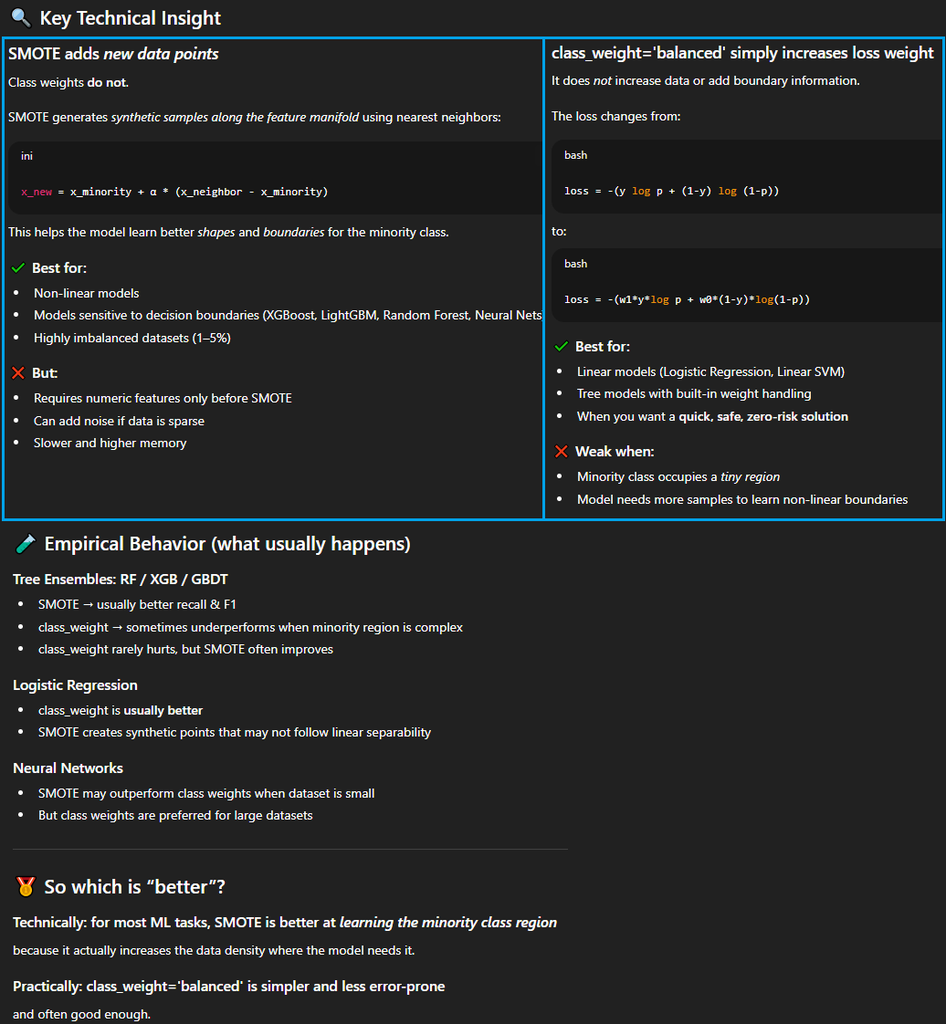

- SMOTE (Synthetic Minority Over‑sampling Technique) : Generates synthetic minority samples instead of duplicates.
- ADASYN (Adaptive Synthetic Sampling) - Variant of SMOTE that focuses on hard-to-classify minority examples.

```python
from imblearn.over_sampling import SMOTE
from imblearn.over_sampling import ADASYN
#The standard Pipeline from sklearn can’t handle resampling steps like SMOTE because resamplers change both X and y during fitting.
#sklearn.pipeline.Pipeline	❌	Only expects transformers that modify X (not y).
#We need to use imbpipeline therefore. - Specifically designed for resampling steps that change both X and y.
from imblearn.pipeline import Pipeline
```

### Logistic Untuned SMOTE

```python
pipeline = Pipeline(steps=[
    ('preprocess', preprocessor),
    ('smote', SMOTE(random_state=42)),
    ('clf', LogisticRegression(random_state=42))

  ])

trained_model = evaluate_model(len(models),"Logistic Untuned SMOTE",pipeline, X_train, X_test, y_train, y_test)
models.append(trained_model)
```

### RandomForest Untuned SMOTE

```python
pipeline = Pipeline(steps=[
    ('preprocess', preprocessor),
    ('smote', SMOTE(random_state=42)),
    ('clf', RandomForestClassifier(random_state=42))

  ])

trained_model = evaluate_model(len(models),"RandomForest Untuned SMOTE",pipeline, X_train, X_test, y_train, y_test)
models.append(trained_model)
```

### RandomForest Untuned ADASYN

```python
######################
pipeline  = Pipeline([
    ('preprocess', preprocessor),
    ('adasyn', ADASYN(random_state=42)),
    ('clf', RandomForestClassifier(random_state=42))
])

trained_model = evaluate_model(len(models),
                               "RandomForest Untuned ADASYN",
                                pipeline,
                                X_train, X_test, y_train, y_test
                            )
models.append(trained_model)
```

### LightGBM Untuned class_weight

```python
######################
pipeline  = Pipeline([
    ('preprocess', preprocessor),
    ('clf', LGBMClassifier(class_weight='balanced',random_state=42))
])

trained_model = evaluate_model(len(models),
                               "LightGBM Untuned class_weight",
                                pipeline,
                                X_train, X_test, y_train, y_test
                            )
models.append(trained_model)
```

[output not shown]

### LightGBM Untuned is_unbalance

```python
######################
pipeline  = Pipeline([
    ('preprocess', preprocessor),
    ('clf', LGBMClassifier(is_unbalance=True,random_state=42, verbose=0))
])

trained_model = evaluate_model(len(models),
                               "LightGBM Untuned is_unbalance",
                                pipeline,
                                X_train, X_test, y_train, y_test
                            )
models.append(trained_model)
```

[output not shown]

### XGBoost Untuned SMOTE

```python
######################
pipeline  = Pipeline([
    ('preprocess', preprocessor),
    ('smote', SMOTE(random_state=42)),
    ('clf', XGBClassifier(random_state=42))
])

trained_model = evaluate_model(len(models),
                               "XGBoost Untuned SMOTE",
                                pipeline,
                                X_train, X_test, y_train, y_test
                            )
models.append(trained_model)
```

### XGBoost Untuned scale_pos_weight

Class Imbalance Handling for XGBoost (XGBClassifier)

- We used SMOTE above
- Here we us scale_pos_weight parameter to see if it gives better result than SMOTE for XGBoost

```python
# 🔥 Best method: scale_pos_weight
# scale_pos_weight = (# negative samples) / (# positive samples)
# This tells XGBoost how important each minority sample is.
# ✔ Why this works best for XGB?
# XGBoost uses gradients and Hessians, so class_weight is not reliable.
# scale_pos_weight directly affects the boosting process.

# compute scale_pos_weight
neg, pos = np.bincount(y_train)
scale_pos_weight = neg / pos
print("scale_pos_weight =", scale_pos_weight)

modelXGB_balanced = Pipeline(steps=[
    ('preprocess', preprocessor),
    ('clf', XGBClassifier(
        random_state=42,
        scale_pos_weight=scale_pos_weight,
        eval_metric='logloss'
    ))
])


######################
pipeline  = Pipeline([
    ('preprocess', preprocessor),
    ('clf', XGBClassifier(
        random_state=42,
        scale_pos_weight=scale_pos_weight,
        eval_metric='logloss'
    ))
])

trained_model = evaluate_model(len(models),
                               "XGBoost Untuned scale_pos_weight",
                                pipeline,
                                X_train, X_test, y_train, y_test
                            )
models.append(trained_model)
```

```
scale_pos_weight = 0.47368421052631576
```

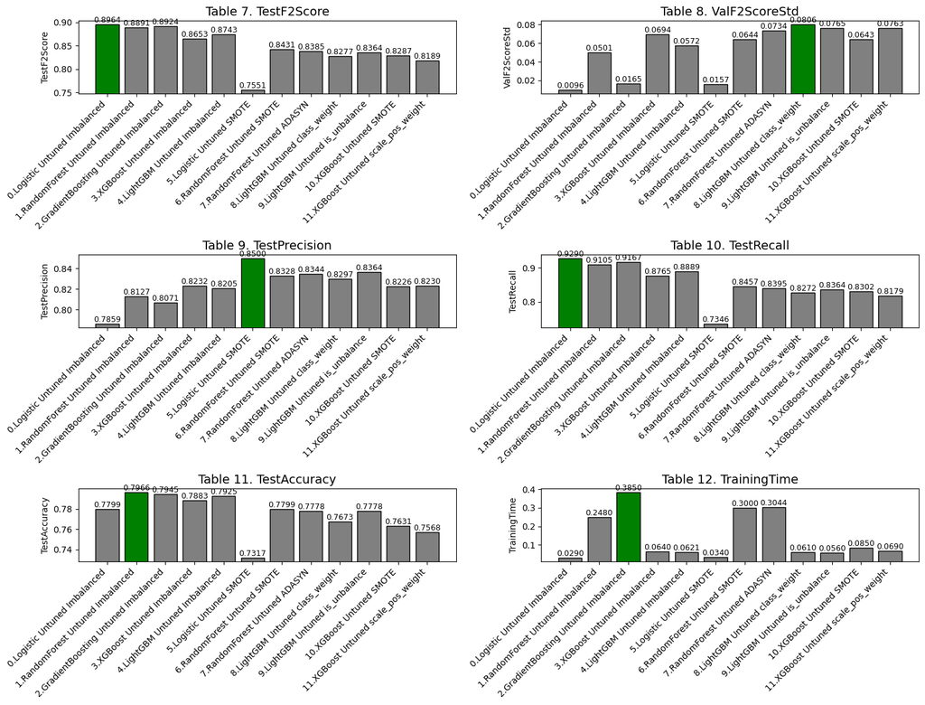

```
                                  Model  TestF2Score
0           Logistic Untuned Imbalanced     0.896367
2   GradientBoosting Untuned Imbalanced     0.892428
1       RandomForest Untuned Imbalanced     0.889090
4           LightGBM Untuned Imbalanced     0.874317
3            XGBoost Untuned Imbalanced     0.865326
6            RandomForest Untuned SMOTE     0.843077
7           RandomForest Untuned ADASYN     0.838471
9         LightGBM Untuned is_unbalance     0.836420
10                XGBoost Untuned SMOTE     0.828712
8         LightGBM Untuned class_weight     0.827671
11     XGBoost Untuned scale_pos_weight     0.818912
5                Logistic Untuned SMOTE     0.755076
```

```python
plot_metrics_grid(results, metrics_to_plot)
```

Strangely, fixing imbalance is reducing F1 and F2 score for ALL algorithms - This begets a question then :

### Discussion : Is using Model trained on Imbalanced Data always bad?

- If the model trained on imbalanced data gives a significantly higher F2 score on the test set, then using the imbalanced model is the correct choice.
- **Why imbalanced training can sometimes beat balanced training**
  - Natural distribution contains signal. If minority-class examples are highly informative, oversampling can blur decision boundaries.
  - Synthetic samples (SMOTE/ADASYN) can introduce noise. They create interpolated points that may be unrealistic and reduce model generalization.
  - Some algorithms handle imbalance inherently. Tree-based models (RF, XGBoost, LightGBM) often split on strong signals and are less helped by naive oversampling.
  - Loss/threshold interactions. Balancing methods may shift model calibration; if you don't re-tune thresholds, evaluation will be unfair.
- ✅ The ONLY thing that matters: Test-set F2 score
  - Not intuition
  - Not guidelines
  - Not “balanced is better” myths
  - 📌 If the test F2 score is higher → that model is better for our churn use case. -We are ~6% better F2 from imbalanced models. **That’s very meaningful in churn prediction.**
- **Conclusion**: balancing is a tool — not an automatic win. Empirical evaluation on a held-out test set and stable CV is the ground truth.
- We need check these two things before finalizing
  - (a) Check stability using cross-validation
    - If the imbalanced model is stable across folds → good.
    - We collected standard deviation of validation F2 scores and it can be seen that Standard deviation of the models is low.
  - (b) Check prediction threshold
    - We used the default 0.5, a balanced model often needs a lower threshold (0.2–0.3) to show its real strength.
    - We will do this during hyper parameter tuning

## 5.5 Lets see if Removing collinear features can further improve results

### Logistic VIF imbalanced

```python
pipeline = Pipeline(steps=[
    ('preprocess', preprocessor),
    ('drop_high_vif', ColumnDropper(
            drop_cols=columns_to_drop,
            all_feature_names=X_train_scaled.columns,  # known feature names from preprocessor
            return_df=False                    # keep as numpy for sklearn models
        )),
    ('clf', LogisticRegression(random_state=42))

  ])

trained_model = evaluate_model(len(models),"Logistic VIF imbalanced",pipeline, X_train, X_test, y_train, y_test)
models.append(trained_model)
```

### RandomForest VIF Imbalanced

```python
pipeline = Pipeline(steps=[
    ('preprocess', preprocessor),
    ('drop_high_vif', ColumnDropper(
            drop_cols=columns_to_drop,
            all_feature_names=X_train_scaled.columns,  # known feature names from preprocessor
            return_df=False                    # keep as numpy for sklearn models
        )),
    ('clf', RandomForestClassifier(random_state=42))

  ])

trained_model = evaluate_model(len(models),"RandomForest VIF Imbalanced",pipeline, X_train, X_test, y_train, y_test)
models.append(trained_model)
```

### GradientBoosting VIF Imbalanced

```python
######################
pipeline  = Pipeline([
    ('preprocess', preprocessor),
    ('drop_high_vif', ColumnDropper(
            drop_cols=columns_to_drop,
            all_feature_names=X_train_scaled.columns,  # known feature names from preprocessor
            return_df=False                    # keep as numpy for sklearn models
        )),
    ('clf', GradientBoostingClassifier(n_estimators=200, max_depth=2, loss = 'log_loss'))
])

trained_model = evaluate_model(len(models),
                               "GradientBoosting VIF Imbalanced",
                                pipeline,
                                X_train, X_test, y_train, y_test
                            )
models.append(trained_model)
```

```python
results[['Model','TestF2Score']].sort_values(by="TestF2Score", ascending=False)
```

|  | Model | TestF2Score |
| --- | --- | --- |
| 14 | GradientBoosting VIF Imbalanced | 0.901198 |
| 0 | Logistic Untuned Imbalanced | 0.896367 |
| 2 | GradientBoosting Untuned Imbalanced | 0.892428 |
| 1 | RandomForest Untuned Imbalanced | 0.889090 |
| 12 | Logistic VIF imbalanced | 0.884110 |
| 4 | LightGBM Untuned Imbalanced | 0.874317 |
| 13 | RandomForest VIF Imbalanced | 0.866788 |
| 3 | XGBoost Untuned Imbalanced | 0.865326 |
| 6 | RandomForest Untuned SMOTE | 0.843077 |
| 7 | RandomForest Untuned ADASYN | 0.838471 |
| 9 | LightGBM Untuned is_unbalance | 0.836420 |
| 10 | XGBoost Untuned SMOTE | 0.828712 |
| 8 | LightGBM Untuned class_weight | 0.827671 |
| 11 | XGBoost Untuned scale_pos_weight | 0.818912 |
| 5 | Logistic Untuned SMOTE | 0.755076 |

Very interestingly, GradientBoosting VIF Imbalanced is the top scorer now (0.9011976047904192)

So removing collinear features helped.

Logistic Untuned Imbalanced and GradientBoosting Untuned Imbalanced are close contenders

## 5.6 Hyper parameter tuning

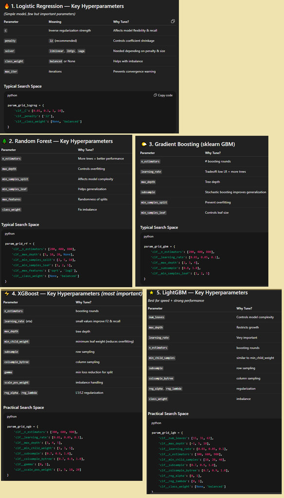

### 5.6.1 Create a Weighted-F2 scorer

- To evaluate models giving preference to F2 score instead of F1, we can create a custom scorer
- Weighted-F2 means β = 2 and average = 'weighted'.

```python
from sklearn.metrics import make_scorer

weighted_f2 = make_scorer(
    fbeta_score,
    beta=2,
    average='weighted'
)
```

### 5.6.2 Tuning Logistic Regression

```python
from sklearn.model_selection import RandomizedSearchCV, GridSearchCV

model = Pipeline(steps=[
    ('preprocess', preprocessor),
    ('clf', LogisticRegression(random_state=42))
])
#As our classifier is inside a pipeline, so the hyperparameters must be referenced using the pipeline step name
param_dist = {
    'clf__C': [0.001,0.002, 0.01],
    'clf__penalty': ['l2'],
    'clf__solver': ['lbfgs', 'liblinear'],
    'clf__class_weight': [None, 'balanced']
}

search = GridSearchCV(
    model,
    param_grid=param_dist,
    scoring=weighted_f2,
    cv=5,
    n_jobs=-1,
    verbose=2
)

search.fit(X_train, y_train)
print(search.best_params_)
print(search.best_score_)
```

```
Fitting 5 folds for each of 12 candidates, totalling 60 fits
{'clf__C': 0.01, 'clf__class_weight': None, 'clf__penalty': 'l2', 'clf__solver': 'lbfgs'}
0.7364465846408762
```

```python
# Create a new pipeline using the best params
tuned_model = Pipeline(steps=[
    ('preprocess', preprocessor),
    ('drop_high_vif', ColumnDropper(
            drop_cols=columns_to_drop,
            all_feature_names=X_train_scaled.columns,  # known feature names from preprocessor
            return_df=False                    # keep as numpy for sklearn models
        )),
    ('clf', LogisticRegression(
        solver='lbfgs',
        penalty='l2',
        C=0.01,
        class_weight=None,
        random_state=42
    ))
])

trained_model = evaluate_model(len(models),"Logistic Tuned VIF Imbalanced",tuned_model, X_train, X_test, y_train, y_test)
models.append(trained_model)
```

#### 5.4.2.2 Doing a manual+visual search for C Parameter

```
Trying for Lambda value of  0.01
Trying for Lambda value of  500.01
Trying for Lambda value of  1000.01
Trying for Lambda value of  1500.01
```

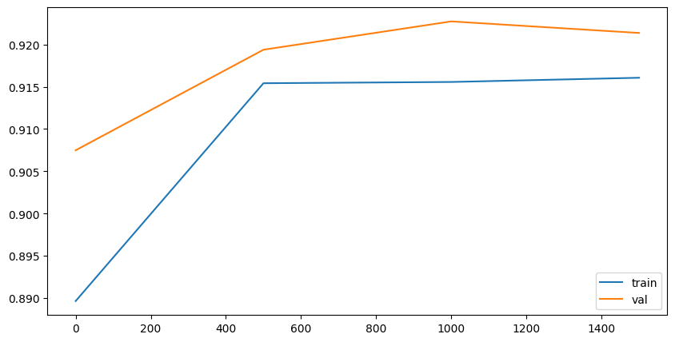

```python
train_scores = []
val_scores = []

#Quick note on stratify=y
# Stratified train-test splitting is a technique used to divide a dataset into training and testing sets while
# preserving the original proportion of classes or categories within the target variable. This is particularly
# crucial in classification tasks, especially when dealing with imbalanced datasets where some classes are
# significantly underrepresented compared to others.
X_train_cv, X_val, y_train_cv, y_val = train_test_split(X_train, y_train, test_size=0.25, random_state=42, stratify=y_train)

for la in np.arange(0.01, 2000.0, 500):
  print("Trying for Lambda value of ",la)
  scaled_lr = Pipeline(steps=[
      ('preprocess', preprocessor),
      ('drop_high_vif', ColumnDropper(
          drop_cols=columns_to_drop,
          all_feature_names=X_train_scaled.columns,  # known feature names from preprocessor
          return_df=False                    # keep as numpy for sklearn models
      )),
      ('classifier', LogisticRegression(C=1/la))
  ])

  scaled_lr.fit(X_train_cv, y_train_cv)

  train_score = fbeta_score(y_train_cv, scaled_lr.predict(X_train_cv), beta=2)
  val_score = fbeta_score(y_val, scaled_lr.predict(X_val), beta=2)

  train_scores.append(train_score)
  val_scores.append(val_score)

#Plot train and val scores
plt.figure(figsize=(10,5))

plt.plot(list(np.arange(0.01, 2000.0, 500)), train_scores, label="train")
plt.plot(list(np.arange(0.01, 2000.0, 500)), val_scores, label="val")
plt.legend(loc='lower right')
```

```python
# Create a new pipeline using the C=1/500
tuned_lr_pipeline  = Pipeline(steps=[
    ('preprocess', preprocessor),
    ('drop_high_vif', ColumnDropper(
            drop_cols=columns_to_drop,
            all_feature_names=X_train_scaled.columns,  # known feature names from preprocessor
            return_df=False                    # keep as numpy for sklearn models
        )),
    ('clf', LogisticRegression(
        solver='lbfgs',
        penalty='l2',
        C=1/500,
        class_weight=None,
        random_state=42
    ))
])

trained_model = evaluate_model(len(models),"Logistic C=1/500 VIF Imbalanced",tuned_lr_pipeline, X_train, X_test, y_train, y_test)
models.append(trained_model)
```

```python
results[['Model','TestF2Score']].sort_values(by="TestF2Score", ascending=False)
```

|  | Model | TestF2Score |
| --- | --- | --- |
| 16 | Logistic C=1/500 VIF Imbalanced | 0.928405 |
| 15 | Logistic Tuned VIF Imbalanced | 0.906416 |
| 14 | GradientBoosting VIF Imbalanced | 0.901198 |
| 0 | Logistic Untuned Imbalanced | 0.896367 |
| 2 | GradientBoosting Untuned Imbalanced | 0.892428 |
| 1 | RandomForest Untuned Imbalanced | 0.889090 |
| 12 | Logistic VIF imbalanced | 0.884110 |
| 4 | LightGBM Untuned Imbalanced | 0.874317 |
| 13 | RandomForest VIF Imbalanced | 0.866788 |
| 3 | XGBoost Untuned Imbalanced | 0.865326 |
| 6 | RandomForest Untuned SMOTE | 0.843077 |
| 7 | RandomForest Untuned ADASYN | 0.838471 |
| 9 | LightGBM Untuned is_unbalance | 0.836420 |
| 10 | XGBoost Untuned SMOTE | 0.828712 |
| 8 | LightGBM Untuned class_weight | 0.827671 |
| 11 | XGBoost Untuned scale_pos_weight | 0.818912 |
| 5 | Logistic Untuned SMOTE | 0.755076 |

#### 5.4.2.2 Lets try polynomial regression too

```python
from sklearn.pipeline import Pipeline
from sklearn.preprocessing import PolynomialFeatures, StandardScaler
from sklearn.linear_model import LogisticRegression

# Create a new pipeline using Polynomial features
pipeline  = Pipeline(steps=[
    ('preprocess', preprocessor),
    ('drop_high_vif', ColumnDropper(
            drop_cols=columns_to_drop,
            all_feature_names=X_train_scaled.columns,  # known feature names from preprocessor
            return_df=False                    # keep as numpy for sklearn models
        )),
    ("poly", PolynomialFeatures(degree=2, include_bias=False)),
    ('clf', LogisticRegression(
        random_state=42
    ))
])

trained_model = evaluate_model(len(models),"Logistic Polynomial VIF Imbalanced",pipeline, X_train, X_test, y_train, y_test)
models.append(trained_model)
```

Performance for Polynomial features with Logistic Regression is slightly less than that with normal linear features.

### 5.6.3 Tuning Random Forest

```python
rf_param_grid = {
    'clf__n_estimators': [200, 400, 600],
    'clf__max_depth': [5, 10, 15, None],
    'clf__min_samples_split': [2, 5, 10],
    'clf__min_samples_leaf': [1, 2, 4],
    'clf__class_weight': [None, 'balanced', 'balanced_subsample'],
    'clf__max_features': ['sqrt', 'log2']
}

model = Pipeline(steps=[
    ('preprocess', preprocessor),
    ('clf', RandomForestClassifier(random_state=42))
])

search = RandomizedSearchCV(
    model,
    param_distributions=rf_param_grid,
    n_iter=35,
    scoring=weighted_f2,
    cv=5,
    n_jobs=-1,
    verbose=2,
    random_state=42
)

search.fit(X_train, y_train)
print(search.best_params_)
print(search.best_score_)
```

```
Fitting 5 folds for each of 35 candidates, totalling 175 fits
{'clf__n_estimators': 200, 'clf__min_samples_split': 10, 'clf__min_samples_leaf': 2, 'clf__max_features': 'sqrt', 'clf__max_depth': 10, 'clf__class_weight': None}
0.7759663611455806
```

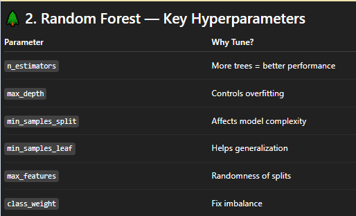

```python
# Create a new pipeline using the best params
tuned_rf_pipeline = Pipeline(steps=[
    ('preprocess', preprocessor),
    ('drop_high_vif', ColumnDropper(
            drop_cols=columns_to_drop,
            all_feature_names=X_train_scaled.columns,  # known feature names from preprocessor
            return_df=False                    # keep as numpy for sklearn models
        )),
    ('clf', RandomForestClassifier(
        n_estimators=200,
        min_samples_split=10,
        min_samples_leaf=2,
        max_features='sqrt',
        max_depth=10,
        class_weight=None,
        random_state=42
    ))
])

trained_model = evaluate_model(len(models),"RandomForest Tuned VIF Imbalanced",tuned_rf_pipeline, X_train, X_test, y_train, y_test)
models.append(trained_model)
```

### 5.6.5 Tuning Gradient Boosting (GBM)

```python
#Why we dont add loss to param grid
#For binary/multi-class classification, 'log_loss' is almost always used because it works well
# with probabilistic metrics like F2-score, F1-score, AUC, etc.
#'exponential' is more like AdaBoost. For modern GBMs, 'log_loss' is almost always preferred for classification
gbm_param_grid = {
    'clf__n_estimators': [100, 200, 300],
    'clf__learning_rate': [0.05, 0.1, 0.2],
    'clf__max_depth': [2, 3, 4],
    'clf__subsample': [0.8, 1.0],
    'clf__min_samples_leaf': [1, 2, 4]
}
model = Pipeline(steps=[
    ('preprocess', preprocessor),
    ('drop_high_vif', ColumnDropper(
            drop_cols=columns_to_drop,
            all_feature_names=X_train_scaled.columns,  # known feature names from preprocessor
            return_df=False                    # keep as numpy for sklearn models
        )),
    ('clf', GradientBoostingClassifier(loss = 'log_loss'))
])

search = RandomizedSearchCV(
    model,
    param_distributions=gbm_param_grid,
    n_iter=20,
    scoring=weighted_f2,
    cv=5,
    n_jobs=-1,
    verbose=2,
    random_state=42
)

search.fit(X_train, y_train)
print(search.best_params_)
print(search.best_score_)
```

```
Fitting 5 folds for each of 20 candidates, totalling 100 fits
{'clf__subsample': 0.8, 'clf__n_estimators': 100, 'clf__min_samples_leaf': 2, 'clf__max_depth': 3, 'clf__learning_rate': 0.05}
0.7762045782006759
```

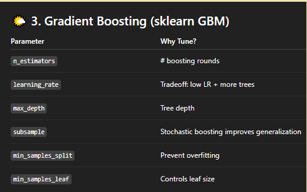

```python
# Create pipeline with preprocessing and tuned GBM
tuned_gbm_pipeline = Pipeline(steps=[
    ('preprocess', preprocessor),
    ('drop_high_vif', ColumnDropper(
            drop_cols=columns_to_drop,
            all_feature_names=X_train_scaled.columns,  # known feature names from preprocessor
            return_df=False                    # keep as numpy for sklearn models
        )),
    ('clf', GradientBoostingClassifier(
        n_estimators=100,
        learning_rate=0.05,
        max_depth=3,
        subsample=0.8,
        min_samples_leaf=2,
        loss='log_loss',  # keep log_loss for classification
        random_state=42
    ))
])

trained_model = evaluate_model(len(models),"GradientBoosting Tuned VIF Imbalanced",tuned_gbm_pipeline, X_train, X_test, y_train, y_test)
models.append(trained_model)
```

```python
results[['Model','TestF2Score']].sort_values(by="TestF2Score", ascending=False)
```

|  | Model | TestF2Score |
| --- | --- | --- |
| 16 | Logistic C=1/500 VIF Imbalanced | 0.928405 |
| 18 | RandomForest Tuned VIF Imbalanced | 0.912365 |
| 19 | GradientBoosting Tuned VIF Imbalanced | 0.911271 |
| 15 | Logistic Tuned VIF Imbalanced | 0.906416 |
| 14 | GradientBoosting VIF Imbalanced | 0.901198 |
| 0 | Logistic Untuned Imbalanced | 0.896367 |
| 17 | Logistic Polynomial VIF Imbalanced | 0.894674 |
| 2 | GradientBoosting Untuned Imbalanced | 0.892428 |
| 1 | RandomForest Untuned Imbalanced | 0.889090 |
| 12 | Logistic VIF imbalanced | 0.884110 |
| 4 | LightGBM Untuned Imbalanced | 0.874317 |
| 13 | RandomForest VIF Imbalanced | 0.866788 |
| 3 | XGBoost Untuned Imbalanced | 0.865326 |
| 6 | RandomForest Untuned SMOTE | 0.843077 |
| 7 | RandomForest Untuned ADASYN | 0.838471 |
| 9 | LightGBM Untuned is_unbalance | 0.836420 |
| 10 | XGBoost Untuned SMOTE | 0.828712 |
| 8 | LightGBM Untuned class_weight | 0.827671 |
| 11 | XGBoost Untuned scale_pos_weight | 0.818912 |
| 5 | Logistic Untuned SMOTE | 0.755076 |

### 5.6.6 Tuning XGBoost

```python
xgb_param_grid = {
    'clf__n_estimators': [200, 400, 600],
    'clf__learning_rate': [0.01, 0.05, 0.1],
    'clf__max_depth': [3, 5, 7],
    'clf__subsample': [0.7, 0.9, 1.0],
    'clf__colsample_bytree': [0.6, 0.8, 1.0],
    'clf__gamma': [0, 1, 5],
    'clf__reg_lambda': [1, 5, 10],
    'clf__scale_pos_weight': [1, 5, 10, 20]   # IMPORTANT for imbalance
}

model = Pipeline(steps=[
    ('preprocess', preprocessor),
    ('drop_high_vif', ColumnDropper(
            drop_cols=columns_to_drop,
            all_feature_names=X_train_scaled.columns,  # known feature names from preprocessor
            return_df=False                    # keep as numpy for sklearn models
        )),
    ('clf', XGBClassifier(random_state=42, eval_metric='logloss'))
])

search = RandomizedSearchCV(
    model,
    param_distributions=xgb_param_grid,
    n_iter=20,
    scoring=weighted_f2,
    cv=5,
    n_jobs=-1,
    verbose=2,
    random_state=42
)

search.fit(X_train, y_train)
print(search.best_params_)
print(search.best_score_)
```

```
Fitting 5 folds for each of 20 candidates, totalling 100 fits
{'clf__subsample': 0.9, 'clf__scale_pos_weight': 1, 'clf__reg_lambda': 1, 'clf__n_estimators': 400, 'clf__max_depth': 5, 'clf__learning_rate': 0.01, 'clf__gamma': 1, 'clf__colsample_bytree': 1.0}
0.7754007841083033
```

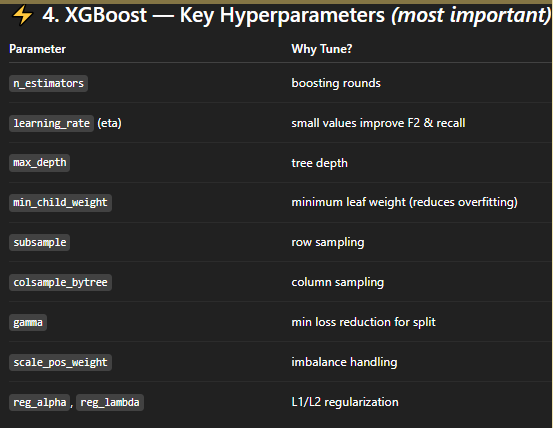

```python
# Create pipeline with preprocessing and tuned XGBoost
tuned_xgb_pipeline = Pipeline(steps=[
    ('preprocess', preprocessor),
    ('drop_high_vif', ColumnDropper(
            drop_cols=columns_to_drop,
            all_feature_names=X_train_scaled.columns,  # known feature names from preprocessor
            return_df=False                    # keep as numpy for sklearn models
        )),
    ('clf', XGBClassifier(
        n_estimators=400,
        learning_rate=0.01,
        max_depth=5,
        subsample=0.9,
        colsample_bytree=1.0,
        gamma=1,
        reg_lambda=1,
        scale_pos_weight=1,
        use_label_encoder=False,  # recommended for modern XGBoost
        eval_metric='logloss',    # prevents warning with use_label_encoder=False
        random_state=42
    ))
])

trained_model = evaluate_model(len(models),"XGBoost Tuned VIF Imbalanced",tuned_xgb_pipeline, X_train, X_test, y_train, y_test)
models.append(trained_model)
```

```python
results[['Model','TestF2Score']].sort_values(by="TestF2Score", ascending=False)
```

|  | Model | TestF2Score |
| --- | --- | --- |
| 16 | Logistic C=1/500 VIF Imbalanced | 0.928405 |
| 18 | RandomForest Tuned VIF Imbalanced | 0.912365 |
| 19 | GradientBoosting Tuned VIF Imbalanced | 0.911271 |
| 15 | Logistic Tuned VIF Imbalanced | 0.906416 |
| 14 | GradientBoosting VIF Imbalanced | 0.901198 |
| 0 | Logistic Untuned Imbalanced | 0.896367 |
| 17 | Logistic Polynomial VIF Imbalanced | 0.894674 |
| 2 | GradientBoosting Untuned Imbalanced | 0.892428 |
| 1 | RandomForest Untuned Imbalanced | 0.889090 |
| 20 | XGBoost Tuned VIF Imbalanced | 0.889090 |
| 12 | Logistic VIF imbalanced | 0.884110 |
| 4 | LightGBM Untuned Imbalanced | 0.874317 |
| 13 | RandomForest VIF Imbalanced | 0.866788 |
| 3 | XGBoost Untuned Imbalanced | 0.865326 |
| 6 | RandomForest Untuned SMOTE | 0.843077 |
| 7 | RandomForest Untuned ADASYN | 0.838471 |
| 9 | LightGBM Untuned is_unbalance | 0.836420 |
| 10 | XGBoost Untuned SMOTE | 0.828712 |
| 8 | LightGBM Untuned class_weight | 0.827671 |
| 11 | XGBoost Untuned scale_pos_weight | 0.818912 |
| 5 | Logistic Untuned SMOTE | 0.755076 |

### 5.6.7 Tuning LightGBM

```python
lgbm_param_grid = {
    'clf__n_estimators': [200, 400, 600],
    'clf__learning_rate': [0.01, 0.05, 0.1],
    'clf__max_depth': [-1, 5, 10],
    'clf__num_leaves': [31, 63, 127],
    'clf__subsample': [0.7, 0.9, 1.0],
    'clf__colsample_bytree': [0.7, 0.9, 1.0],
    'clf__reg_lambda': [0.1, 1, 5],
    'clf__class_weight': [None, 'balanced'],
    'clf__scale_pos_weight': [1, 5, 10, 20]  # alternative imbalance control
}

model = Pipeline(steps=[
    ('preprocess', preprocessor),
    ('drop_high_vif', ColumnDropper(
            drop_cols=columns_to_drop,
            all_feature_names=X_train_scaled.columns,  # known feature names from preprocessor
            return_df=False                    # keep as numpy for sklearn models
        )),
    ('clf', LGBMClassifier(random_state=42))
])

search = RandomizedSearchCV(
    model,
    param_distributions=lgbm_param_grid,
    n_iter=20,
    scoring=weighted_f2,
    cv=5,
    n_jobs=-1,
    verbose=0,
    random_state=42
)

search.fit(X_train, y_train)
print(search.best_params_)
print(search.best_score_)
```

[output not shown]

[output cut: 347 more lines]

[output not shown]

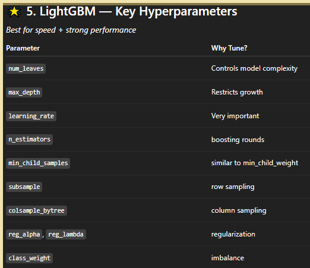

```python
# Create pipeline with preprocessing and tuned LightGBM
tuned_lgbm_pipeline = Pipeline(steps=[
    ('preprocess', preprocessor),
    ('drop_high_vif', ColumnDropper(
            drop_cols=columns_to_drop,
            all_feature_names=X_train_scaled.columns,  # known feature names from preprocessor
            return_df=False                    # keep as numpy for sklearn models
        )),
    ('clf', LGBMClassifier(
        n_estimators=400,
        learning_rate=0.01,
        max_depth=5,
        num_leaves=31,
        subsample=0.9,
        colsample_bytree=1.0,
        reg_lambda=0.1,
        scale_pos_weight=1,
        class_weight=None,
        random_state=42,
        verbose=0
    ))
])

trained_model = evaluate_model(len(models),"LightGBM Tuned VIF Imbalanced",tuned_lgbm_pipeline, X_train, X_test, y_train, y_test)
models.append(trained_model)
results[['Model','TestF2Score']].sort_values(by="TestF2Score", ascending=False)
```

[output not shown]

[output cut: 345 more lines]

[output not shown]

[output not shown]

[output not shown]

[output cut: 345 more lines]

[output not shown]

|  | Model | TestF2Score |
| --- | --- | --- |
| 16 | Logistic C=1/500 VIF Imbalanced | 0.928405 |
| 18 | RandomForest Tuned VIF Imbalanced | 0.912365 |
| 19 | GradientBoosting Tuned VIF Imbalanced | 0.911271 |
| 15 | Logistic Tuned VIF Imbalanced | 0.906416 |
| 14 | GradientBoosting VIF Imbalanced | 0.901198 |
| 0 | Logistic Untuned Imbalanced | 0.896367 |
| 21 | LightGBM Tuned VIF Imbalanced | 0.895657 |
| 17 | Logistic Polynomial VIF Imbalanced | 0.894674 |
| 2 | GradientBoosting Untuned Imbalanced | 0.892428 |
| 1 | RandomForest Untuned Imbalanced | 0.889090 |
| 20 | XGBoost Tuned VIF Imbalanced | 0.889090 |
| 12 | Logistic VIF imbalanced | 0.884110 |
| 4 | LightGBM Untuned Imbalanced | 0.874317 |
| 13 | RandomForest VIF Imbalanced | 0.866788 |
| 3 | XGBoost Untuned Imbalanced | 0.865326 |
| 6 | RandomForest Untuned SMOTE | 0.843077 |
| 7 | RandomForest Untuned ADASYN | 0.838471 |
| 9 | LightGBM Untuned is_unbalance | 0.836420 |
| 10 | XGBoost Untuned SMOTE | 0.828712 |
| 8 | LightGBM Untuned class_weight | 0.827671 |
| 11 | XGBoost Untuned scale_pos_weight | 0.818912 |
| 5 | Logistic Untuned SMOTE | 0.755076 |

### 5.6.8 Tuning Naive Bayes

```python
pipeline = Pipeline(steps=[
    ("preprocess", preprocessor),
    ('drop_high_vif', ColumnDropper(
            drop_cols=columns_to_drop,
            all_feature_names=X_train_scaled.columns,  # known feature names from preprocessor
            return_df=False                    # keep as numpy for sklearn models
        )),
    ("clf", GaussianNB())
])
trained_model = evaluate_model(len(models),"NaiveBayes Gaussian VIF Imbalanced",pipeline, X_train, X_test, y_train, y_test)
models.append(trained_model)
```

```python
r = results[['Model','TestF2Score']].sort_values(by="TestF2Score", ascending=False)
r.loc[r.Model.str.contains('Naive')]
r.loc[r.Model.str.contains('SVM')]
```

|  | Model | TestF2Score |
| --- | --- | --- |

### 5.6.9 Tuning SVC Linear

```python
from sklearn.svm import SVC

pipeline = Pipeline(steps=[
    ("preprocess", preprocessor),
    ('drop_high_vif', ColumnDropper(
            drop_cols=columns_to_drop,
            all_feature_names=X_train_scaled.columns,  # known feature names from preprocessor
            return_df=False                    # keep as numpy for sklearn models
        )),
    ("clf", SVC(kernel="linear", probability=True))
])
trained_model = evaluate_model(len(models),"SVCLinear Untuned VIF Imbalanced",pipeline, X_train, X_test, y_train, y_test)
models.append(trained_model)
results[['Model','TestF2Score']].sort_values(by="TestF2Score", ascending=False)
```

|  | Model | TestF2Score |
| --- | --- | --- |
| 16 | Logistic C=1/500 VIF Imbalanced | 0.928405 |
| 23 | SVCLinear Untuned VIF Imbalanced | 0.922444 |
| 18 | RandomForest Tuned VIF Imbalanced | 0.912365 |
| 19 | GradientBoosting Tuned VIF Imbalanced | 0.911271 |
| 15 | Logistic Tuned VIF Imbalanced | 0.906416 |
| 14 | GradientBoosting VIF Imbalanced | 0.901198 |
| 0 | Logistic Untuned Imbalanced | 0.896367 |
| 21 | LightGBM Tuned VIF Imbalanced | 0.895657 |
| 17 | Logistic Polynomial VIF Imbalanced | 0.894674 |
| 2 | GradientBoosting Untuned Imbalanced | 0.892428 |
| 20 | XGBoost Tuned VIF Imbalanced | 0.889090 |
| 1 | RandomForest Untuned Imbalanced | 0.889090 |
| 12 | Logistic VIF imbalanced | 0.884110 |
| 22 | NaiveBayes Gaussian VIF Imbalanced | 0.877297 |
| 4 | LightGBM Untuned Imbalanced | 0.874317 |
| 13 | RandomForest VIF Imbalanced | 0.866788 |
| 3 | XGBoost Untuned Imbalanced | 0.865326 |
| 6 | RandomForest Untuned SMOTE | 0.843077 |
| 7 | RandomForest Untuned ADASYN | 0.838471 |
| 9 | LightGBM Untuned is_unbalance | 0.836420 |
| 10 | XGBoost Untuned SMOTE | 0.828712 |
| 8 | LightGBM Untuned class_weight | 0.827671 |
| 11 | XGBoost Untuned scale_pos_weight | 0.818912 |
| 5 | Logistic Untuned SMOTE | 0.755076 |

- Results are promising. We are getting 0.922 even without any tuning ! which is in ball park of the best tuned model till now!
- Lets tune

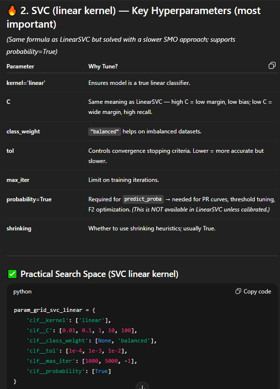

```python
model = Pipeline(steps=[
    ('preprocess', preprocessor),
    ('drop_high_vif', ColumnDropper(
            drop_cols=columns_to_drop,
            all_feature_names=X_train_scaled.columns,  # known feature names from preprocessor
            return_df=False                    # keep as numpy for sklearn models
        )),
    ("clf", SVC())
])

param_dist = {
    "clf__kernel": ["linear"],
    "clf__C": [0.01, 0.1, 1, 10, 100, 500],
    "clf__class_weight": [None, "balanced"],
    "clf__tol": [1e-4, 1e-3, 1e-2],
    "clf__max_iter": [1000, 5000, -1],   # -1 = no limit
    "clf__probability": [True],          # keeps predict_proba
}


search = RandomizedSearchCV(
    estimator=model,
    param_distributions=param_dist,
    n_iter=20,
    scoring=weighted_f2,
    cv=5,
    verbose=1,
    n_jobs=-1,
    random_state=42
)

search.fit(X_train, y_train)
print(search.best_params_)
print(search.best_score_)
```

```
Fitting 5 folds for each of 20 candidates, totalling 100 fits
{'clf__tol': 0.0001, 'clf__probability': True, 'clf__max_iter': 1000, 'clf__kernel': 'linear', 'clf__class_weight': 'balanced', 'clf__C': 1}
0.7421598779349828
```

```python
# Create a new pipeline using the best params
tuned_model = Pipeline(steps=[
    ('preprocess', preprocessor),
    ('drop_high_vif', ColumnDropper(
            drop_cols=columns_to_drop,
            all_feature_names=X_train_scaled.columns,  # known feature names from preprocessor
            return_df=False                    # keep as numpy for sklearn models
        )),
    ("clf", SVC(
        kernel="linear",
        C=1,
        tol=0.0001,
        class_weight='balanced',
        max_iter=-1,
        probability=True   # required for predict_proba
    ))
])

trained_model = evaluate_model(len(models),"SVCLinear Tuned VIF Imbalanced",tuned_model, X_train, X_test, y_train, y_test)
models.append(trained_model)
```

```python
results[['Model','TestF2Score']].sort_values(by="TestF2Score", ascending=False)
```

|  | Model | TestF2Score |
| --- | --- | --- |
| 16 | Logistic C=1/500 VIF Imbalanced | 0.928405 |
| 23 | SVCLinear Untuned VIF Imbalanced | 0.922444 |
| 18 | RandomForest Tuned VIF Imbalanced | 0.912365 |
| 19 | GradientBoosting Tuned VIF Imbalanced | 0.911271 |
| 15 | Logistic Tuned VIF Imbalanced | 0.906416 |
| 14 | GradientBoosting VIF Imbalanced | 0.901198 |
| 0 | Logistic Untuned Imbalanced | 0.896367 |
| 21 | LightGBM Tuned VIF Imbalanced | 0.895657 |
| 17 | Logistic Polynomial VIF Imbalanced | 0.894674 |
| 2 | GradientBoosting Untuned Imbalanced | 0.892428 |
| 20 | XGBoost Tuned VIF Imbalanced | 0.889090 |
| 1 | RandomForest Untuned Imbalanced | 0.889090 |
| 12 | Logistic VIF imbalanced | 0.884110 |
| 22 | NaiveBayes Gaussian VIF Imbalanced | 0.877297 |
| 4 | LightGBM Untuned Imbalanced | 0.874317 |
| 13 | RandomForest VIF Imbalanced | 0.866788 |
| 3 | XGBoost Untuned Imbalanced | 0.865326 |
| 6 | RandomForest Untuned SMOTE | 0.843077 |
| 7 | RandomForest Untuned ADASYN | 0.838471 |
| 9 | LightGBM Untuned is_unbalance | 0.836420 |
| 10 | XGBoost Untuned SMOTE | 0.828712 |
| 8 | LightGBM Untuned class_weight | 0.827671 |
| 11 | XGBoost Untuned scale_pos_weight | 0.818912 |
| 24 | SVCLinear Tuned VIF Imbalanced | 0.772613 |
| 5 | Logistic Untuned SMOTE | 0.755076 |

### 5.6.10 Tuning SVC checking for all kernels

```python
model = Pipeline(steps=[
    ('preprocess', preprocessor),
    ("clf", SVC(probability=True))
])

param_dist = {
    "clf__kernel": ["linear", "poly", "rbf"],
    "clf__C": [0.01, 0.1, 1, 10, 100],
    "clf__gamma": ["scale", "auto"],
    "clf__degree": [2, 3, 4],               # used only if kernel='poly'
    "clf__class_weight": [None, "balanced"],
}


search = RandomizedSearchCV(
    estimator=model,
    param_distributions=param_dist,
    n_iter=25,
    scoring=weighted_f2,
    cv=5,
    verbose=1,
    n_jobs=-1,
    random_state=42
)
search.fit(X_train, y_train)
print(search.best_params_)
print(search.best_score_)
```

```
Fitting 5 folds for each of 25 candidates, totalling 125 fits
{'clf__kernel': 'rbf', 'clf__gamma': 'auto', 'clf__degree': 2, 'clf__class_weight': None, 'clf__C': 10}
0.7669279956370307
```

```python
# Create a new pipeline using the best params
tuned_model = Pipeline(steps=[
    ('preprocess', preprocessor),
    ('drop_high_vif', ColumnDropper(
            drop_cols=columns_to_drop,
            all_feature_names=X_train_scaled.columns,  # known feature names from preprocessor
            return_df=False                    # keep as numpy for sklearn models
        )),
    ("clf", SVC(
        kernel='rbf',
        gamma='auto',
        degree=2,
        class_weight=None,
        C=10,
        probability=True        # keeping this ON to get predict_proba
    ))
])

trained_model = evaluate_model(len(models),"SVC RBF Tuned VIF Imbalanced",tuned_model, X_train, X_test, y_train, y_test)
models.append(trained_model)
```

```python
results[['Model','TestF2Score']].sort_values(by="TestF2Score", ascending=False)
```

|  | Model | TestF2Score |
| --- | --- | --- |
| 16 | Logistic C=1/500 VIF Imbalanced | 0.928405 |
| 23 | SVCLinear Untuned VIF Imbalanced | 0.922444 |
| 25 | SVC RBF Tuned VIF Imbalanced | 0.913947 |
| 18 | RandomForest Tuned VIF Imbalanced | 0.912365 |
| 19 | GradientBoosting Tuned VIF Imbalanced | 0.911271 |
| 15 | Logistic Tuned VIF Imbalanced | 0.906416 |
| 14 | GradientBoosting VIF Imbalanced | 0.901198 |
| 0 | Logistic Untuned Imbalanced | 0.896367 |
| 21 | LightGBM Tuned VIF Imbalanced | 0.895657 |
| 17 | Logistic Polynomial VIF Imbalanced | 0.894674 |
| 2 | GradientBoosting Untuned Imbalanced | 0.892428 |
| 20 | XGBoost Tuned VIF Imbalanced | 0.889090 |
| 1 | RandomForest Untuned Imbalanced | 0.889090 |
| 12 | Logistic VIF imbalanced | 0.884110 |
| 22 | NaiveBayes Gaussian VIF Imbalanced | 0.877297 |
| 4 | LightGBM Untuned Imbalanced | 0.874317 |
| 13 | RandomForest VIF Imbalanced | 0.866788 |
| 3 | XGBoost Untuned Imbalanced | 0.865326 |
| 6 | RandomForest Untuned SMOTE | 0.843077 |
| 7 | RandomForest Untuned ADASYN | 0.838471 |
| 9 | LightGBM Untuned is_unbalance | 0.836420 |
| 10 | XGBoost Untuned SMOTE | 0.828712 |
| 8 | LightGBM Untuned class_weight | 0.827671 |
| 11 | XGBoost Untuned scale_pos_weight | 0.818912 |
| 24 | SVCLinear Tuned VIF Imbalanced | 0.772613 |
| 5 | Logistic Untuned SMOTE | 0.755076 |